# Group Members:

- Zahra Hoobakht

## 1. Load, Split, and Balance

loading data and necessary library packages

```python
#%pip install hdbscan
import pandas as pd
import numpy as np
from scipy.special import expit
import sys
import missingno as mn
import matplotlib.pyplot as plt
from matplotlib import pyplot as plt
from sklearn import preprocessing
from sklearn.preprocessing import StandardScaler
from sklearn.impute import KNNImputer
from sklearn.model_selection import train_test_split
import seaborn as sns
from scipy.special import expit
import copy
from sklearn.metrics import accuracy_score
import warnings
from scipy.optimize import fmin_bfgs # maybe the most common bfgs algorithm in the world
from numpy import ma
from sklearn.linear_model import LogisticRegression
warnings.filterwarnings("ignore", category=FutureWarning)
```

## (1) Load the data into memory and save it to a pandas data frame. Do not normalize or one-hot encode any of the features until asked to do so later in the rubric.

```python
df = pd.read_csv('C://Users/Hedieh/Documents/SMU/ML-Py/lab4/acs2017_census_tract_data.csv')
df.head()
```

|  | TractId | State | County | TotalPop | Men | Women | Hispanic | White | Black | Native | ... | Walk | OtherTransp | WorkAtHome | MeanCommute | Employed | PrivateWork | PublicWork | SelfEmployed | FamilyWork | Unemployment |
| --- | --- | --- | --- | --- | --- | --- | --- | --- | --- | --- | --- | --- | --- | --- | --- | --- | --- | --- | --- | --- | --- |
| 0 | 1001020100 | Alabama | Autauga County | 1845 | 899 | 946 | 2.4 | 86.3 | 5.2 | 0.0 | ... | 0.5 | 0.0 | 2.1 | 24.5 | 881 | 74.2 | 21.2 | 4.5 | 0.0 | 4.6 |
| 1 | 1001020200 | Alabama | Autauga County | 2172 | 1167 | 1005 | 1.1 | 41.6 | 54.5 | 0.0 | ... | 0.0 | 0.5 | 0.0 | 22.2 | 852 | 75.9 | 15.0 | 9.0 | 0.0 | 3.4 |
| 2 | 1001020300 | Alabama | Autauga County | 3385 | 1533 | 1852 | 8.0 | 61.4 | 26.5 | 0.6 | ... | 1.0 | 0.8 | 1.5 | 23.1 | 1482 | 73.3 | 21.1 | 4.8 | 0.7 | 4.7 |
| 3 | 1001020400 | Alabama | Autauga County | 4267 | 2001 | 2266 | 9.6 | 80.3 | 7.1 | 0.5 | ... | 1.5 | 2.9 | 2.1 | 25.9 | 1849 | 75.8 | 19.7 | 4.5 | 0.0 | 6.1 |
| 4 | 1001020500 | Alabama | Autauga County | 9965 | 5054 | 4911 | 0.9 | 77.5 | 16.4 | 0.0 | ... | 0.8 | 0.3 | 0.7 | 21.0 | 4787 | 71.4 | 24.1 | 4.5 | 0.0 | 2.3 |

5 rows × 37 columns

| Attribute | Attr. type | Description |
| --- | --- | --- |
| TractID | Nominal | identification number of individual surveyed |
| State | Nominal | State of individual surveyed. |
| County | Nominal | County of individual surveyed. |
| TotalPop | Ratio | Total population of individual surveyed. |
| all other columns | Ratio | information about individual in survey |

```python
df.describe()
```

|  | TractId | TotalPop | Men | Women | Hispanic | White | Black | Native | Asian | Pacific | ... | Walk | OtherTransp | WorkAtHome | MeanCommute | Employed | PrivateWork | PublicWork | SelfEmployed | FamilyWork | Unemployment |
| --- | --- | --- | --- | --- | --- | --- | --- | --- | --- | --- | --- | --- | --- | --- | --- | --- | --- | --- | --- | --- | --- |
| count | 7.400100e+04 | 74001.000000 | 74001.000000 | 74001.000000 | 73305.000000 | 73305.000000 | 73305.00000 | 73305.000000 | 73305.000000 | 73305.000000 | ... | 73200.000000 | 73200.000000 | 73200.000000 | 73055.000000 | 74001.000000 | 73190.000000 | 73190.000000 | 73190.000000 | 73190.000000 | 73191.000000 |
| mean | 2.839113e+10 | 4384.716017 | 2157.710707 | 2227.005311 | 17.265444 | 61.309043 | 13.28910 | 0.734047 | 4.753691 | 0.147341 | ... | 3.042825 | 1.894605 | 4.661466 | 26.056594 | 2049.152052 | 79.494222 | 14.163342 | 6.171484 | 0.171164 | 7.246738 |
| std | 1.647593e+10 | 2228.936729 | 1120.560504 | 1146.240218 | 23.073811 | 30.634461 | 21.60118 | 4.554247 | 8.999888 | 1.029250 | ... | 5.805753 | 2.549374 | 4.014940 | 7.124524 | 1138.865457 | 8.126383 | 7.328680 | 3.932364 | 0.456580 | 5.227624 |
| min | 1.001020e+09 | 0.000000 | 0.000000 | 0.000000 | 0.000000 | 0.000000 | 0.00000 | 0.000000 | 0.000000 | 0.000000 | ... | 0.000000 | 0.000000 | 0.000000 | 1.000000 | 0.000000 | 0.000000 | 0.000000 | 0.000000 | 0.000000 | 0.000000 |
| 25% | 1.303901e+10 | 2903.000000 | 1416.000000 | 1465.000000 | 2.600000 | 38.000000 | 0.80000 | 0.000000 | 0.200000 | 0.000000 | ... | 0.400000 | 0.400000 | 2.000000 | 21.100000 | 1276.000000 | 75.200000 | 9.300000 | 3.500000 | 0.000000 | 3.900000 |
| 50% | 2.804700e+10 | 4105.000000 | 2007.000000 | 2082.000000 | 7.400000 | 70.400000 | 3.80000 | 0.000000 | 1.500000 | 0.000000 | ... | 1.400000 | 1.200000 | 3.800000 | 25.400000 | 1895.000000 | 80.600000 | 13.000000 | 5.500000 | 0.000000 | 6.000000 |
| 75% | 4.200341e+10 | 5506.000000 | 2707.000000 | 2803.000000 | 21.100000 | 87.700000 | 14.60000 | 0.400000 | 5.000000 | 0.000000 | ... | 3.300000 | 2.500000 | 6.300000 | 30.300000 | 2635.000000 | 85.000000 | 17.600000 | 8.000000 | 0.000000 | 9.000000 |
| max | 7.215375e+10 | 65528.000000 | 32266.000000 | 33262.000000 | 100.000000 | 100.000000 | 100.00000 | 100.000000 | 100.000000 | 71.900000 | ... | 100.000000 | 100.000000 | 100.000000 | 73.900000 | 28945.000000 | 100.000000 | 100.000000 | 100.000000 | 22.300000 | 100.000000 |

8 rows × 35 columns

I checked for duplicates value and I removed TractId column because it does not include any data

```python
# compare the length of list and set to check if the dataset contains duplicates
if len(set(df.TractId)) != len(df.TractId):
    print("duplicates found in the list")
else:
    print("No duplicates found in the list")
```

```
No duplicates found in the list
```

```python
del df['TractId']
```

```python
print(df.info())
```

```
<class 'pandas.core.frame.DataFrame'>
RangeIndex: 74001 entries, 0 to 74000
Data columns (total 36 columns):
 #   Column            Non-Null Count  Dtype
---  ------            --------------  -----
 0   State             74001 non-null  object
 1   County            74001 non-null  object
 2   TotalPop          74001 non-null  int64
 3   Men               74001 non-null  int64
 4   Women             74001 non-null  int64
 5   Hispanic          73305 non-null  float64
 6   White             73305 non-null  float64
 7   Black             73305 non-null  float64
 8   Native            73305 non-null  float64
 9   Asian             73305 non-null  float64
```

[output cut: 29 more lines]

## (2) Remove any observations that having missing data.

```python
df.dropna(inplace=True)
```

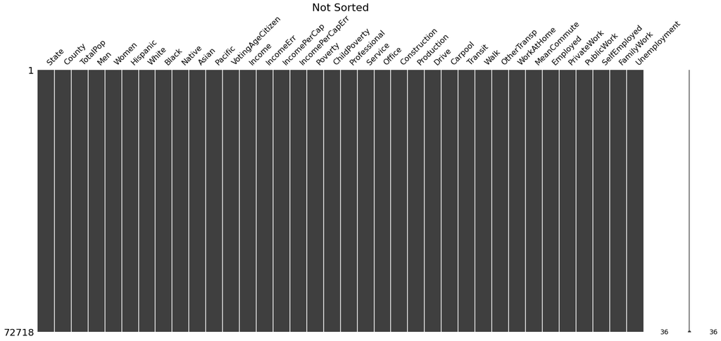

```python
mn.matrix(df)
plt.title("Not Sorted",fontsize=22)
plt.figure()
plt.show()
```

as you can see in above we have no missing data.  
In following cell we can find the information in our categorical data, State and County.

```python
# compare the length of list and set to check if the dataset contains duplicates
categorical_features_column=['State','County']
for col in categorical_features_column:
    print(df[col].value_counts())
```

```
California              7932
Texas                   5197
New York                4778
Florida                 4120
Pennsylvania            3174
Illinois                3105
Ohio                    2931
Michigan                2726
North Carolina          2159
New Jersey              1981
Georgia                 1950
Virginia                1859
Indiana                 1498
Arizona                 1484
Tennessee               1469
Massachusetts           1452
Washington              1441
Missouri                1384
Wisconsin               1382
Maryland                1376
Minnesota               1331
Colorado                1230
Alabama                 1173
Louisiana               1121
Kentucky                1103
South Carolina          1081
Oklahoma                1038
Puerto Rico              875
Oregon                   824
Iowa                     822
Connecticut              814
Kansas                   759
Arkansas                 683
Nevada                   672
Mississippi              654
Utah                     582
Nebraska                 527
New Mexico               498
West Virginia            483
Maine                    351
```

[output cut: 10 more lines]

```
Alaska                   165
Wyoming                  131
Name: State, dtype: int64
Los Angeles County    2300
Cook County           1317
Orange County          929
Maricopa County        885
Montgomery County      822
                      ...
Buena Vista city         1
Meagher County           1
Norton County            1
McCone County            1
Schleicher County        1
Name: County, Length: 1954, dtype: int64
```

```python
print("The number of unique states in this survey is",df["State"].nunique())
print("The number of unique county in this survey is",df["County"].nunique())
```

```
The number of unique states in this survey is 52
The number of unique county in this survey is 1954
```

## (3) Encode any string data as integers for now.

```python
StatesuniqueValues = (df['State']).unique()
CountysuniqueValues = (df['County']).unique()
n=0
statenamenumber=[]
for i in StatesuniqueValues:

    df.State.replace(to_replace = str(i), value =n, inplace = True)
    statenamenumber.append((i,n))
    n+=1
print(statenamenumber)
m=0
Countynamenumber=[]
for j in CountysuniqueValues:
    df.County.replace(to_replace = str(j), value =m, inplace = True)
    Countynamenumber.append((j,m))
    m+=1
#print(Countynamenumber)
print((df['State']).unique())
print((df['County']).unique())
print(df['State'].value_counts())
print(df['County'].value_counts())
```

```
[('Alabama', 0), ('Alaska', 1), ('Arizona', 2), ('Arkansas', 3), ('California', 4), ('Colorado', 5), ('Connecticut', 6), ('Delaware', 7), ('District of Columbia', 8), ('Florida', 9), ('Georgia', 10), ('Hawaii', 11), ('Idaho', 12), ('Illinois', 13), ('Indiana', 14), ('Iowa', 15), ('Kansas', 16), ('Ke…
[ 0  1  2  3  4  5  6  7  8  9 10 11 12 13 14 15 16 17 18 19 20 21 22 23
 24 25 26 27 28 29 30 31 32 33 34 35 36 37 38 39 40 41 42 43 44 45 46 47
 48 49 50 51]
[   0    1    2 ... 1951 1952 1953]
4     7932
43    5197
32    4778
9     4120
38    3174
13    3105
35    2931
22    2726
33    2159
30    1981
```

[output cut: 55 more lines]

## (4) You have the option of keeping the "county" variable or removing it. Be sure to discuss why you decided to keep/remove this variable.

I am going to remove this variable because as it can be seen in the above cell, the number of counties in this survey is not equal and they have very different population so if we don't remove it, it gaves us a biased data prediction where the model may have a tendency to favor the majority class, resulting in poor predictions for the minority class.

```python
del df['County']
df.head(15)
```

|  | State | TotalPop | Men | Women | Hispanic | White | Black | Native | Asian | Pacific | ... | Walk | OtherTransp | WorkAtHome | MeanCommute | Employed | PrivateWork | PublicWork | SelfEmployed | FamilyWork | Unemployment |
| --- | --- | --- | --- | --- | --- | --- | --- | --- | --- | --- | --- | --- | --- | --- | --- | --- | --- | --- | --- | --- | --- |
| 0 | 0 | 1845 | 899 | 946 | 2.4 | 86.3 | 5.2 | 0.0 | 1.2 | 0.0 | ... | 0.5 | 0.0 | 2.1 | 24.5 | 881 | 74.2 | 21.2 | 4.5 | 0.0 | 4.6 |
| 1 | 0 | 2172 | 1167 | 1005 | 1.1 | 41.6 | 54.5 | 0.0 | 1.0 | 0.0 | ... | 0.0 | 0.5 | 0.0 | 22.2 | 852 | 75.9 | 15.0 | 9.0 | 0.0 | 3.4 |
| 2 | 0 | 3385 | 1533 | 1852 | 8.0 | 61.4 | 26.5 | 0.6 | 0.7 | 0.4 | ... | 1.0 | 0.8 | 1.5 | 23.1 | 1482 | 73.3 | 21.1 | 4.8 | 0.7 | 4.7 |
| 3 | 0 | 4267 | 2001 | 2266 | 9.6 | 80.3 | 7.1 | 0.5 | 0.2 | 0.0 | ... | 1.5 | 2.9 | 2.1 | 25.9 | 1849 | 75.8 | 19.7 | 4.5 | 0.0 | 6.1 |
| 4 | 0 | 9965 | 5054 | 4911 | 0.9 | 77.5 | 16.4 | 0.0 | 3.1 | 0.0 | ... | 0.8 | 0.3 | 0.7 | 21.0 | 4787 | 71.4 | 24.1 | 4.5 | 0.0 | 2.3 |
| 5 | 0 | 3620 | 1765 | 1855 | 3.0 | 70.7 | 25.1 | 0.0 | 0.0 | 0.0 | ... | 0.7 | 3.5 | 8.0 | 21.1 | 1364 | 84.0 | 14.1 | 1.9 | 0.0 | 6.1 |
| 6 | 0 | 3420 | 1459 | 1961 | 4.0 | 78.0 | 13.7 | 0.6 | 0.0 | 0.0 | ... | 0.0 | 0.0 | 0.0 | 16.4 | 1418 | 77.4 | 17.6 | 5.0 | 0.0 | 16.9 |
| 7 | 0 | 2913 | 1495 | 1418 | 4.2 | 86.3 | 7.1 | 1.5 | 0.0 | 0.0 | ... | 0.0 | 0.7 | 5.2 | 24.6 | 1369 | 72.7 | 17.5 | 8.8 | 1.0 | 7.2 |
| 8 | 0 | 11333 | 5488 | 5845 | 1.4 | 81.8 | 15.3 | 0.0 | 1.0 | 0.0 | ... | 0.0 | 0.0 | 2.2 | 27.4 | 4857 | 70.1 | 22.5 | 7.4 | 0.0 | 2.2 |
| 9 | 0 | 6167 | 3111 | 3056 | 1.0 | 86.2 | 9.7 | 0.8 | 0.3 | 0.0 | ... | 0.0 | 5.0 | 5.9 | 35.6 | 2781 | 80.4 | 14.5 | 5.0 | 0.0 | 6.8 |
| 10 | 0 | 2796 | 1440 | 1356 | 0.8 | 71.5 | 25.7 | 0.8 | 0.0 | 0.0 | ... | 3.5 | 0.4 | 1.1 | 35.6 | 1202 | 75.4 | 19.0 | 5.7 | 0.0 | 6.0 |
| 11 | 0 | 3153 | 1487 | 1666 | 0.7 | 46.3 | 53.0 | 0.0 | 0.0 | 0.0 | ... | 0.4 | 3.2 | 2.1 | 31.8 | 1270 | 69.4 | 24.7 | 5.8 | 0.0 | 5.4 |
| 12 | 0 | 3988 | 2170 | 1818 | 0.3 | 75.4 | 18.3 | 5.1 | 0.0 | 0.0 | ... | 0.0 | 2.1 | 0.7 | 39.3 | 1598 | 73.8 | 20.4 | 5.8 | 0.0 | 5.8 |
| 13 | 0 | 3259 | 1522 | 1737 | 0.3 | 86.7 | 10.5 | 0.7 | 0.0 | 0.0 | ... | 0.8 | 2.8 | 0.0 | 29.0 | 1340 | 84.4 | 9.6 | 6.0 | 0.0 | 7.8 |
| 14 | 0 | 9056 | 4378 | 4678 | 2.6 | 79.2 | 15.9 | 0.9 | 0.0 | 0.0 | ... | 0.8 | 1.2 | 3.7 | 31.1 | 3340 | 83.5 | 14.5 | 2.0 | 0.0 | 3.9 |

15 rows × 35 columns

## The next two requirements will need to be completed together as they might depend on one another:

[.5 points] Balance the dataset so that about the same number of instances are within each class. Choose a method for balancing the dataset and explain your reasoning for selecting this method. One option is to choose quantization thresholds for the "ChildPoverty" variable that equally divide the data into four classes. Should balancing of the dataset be done for both the training and testing set? Explain.

```python
df.describe()['ChildPoverty']
```

```
count    72718.000000
mean        21.148476
std         18.572714
min          0.000000
25%          6.200000
50%         16.300000
75%         31.600000
max        100.000000
Name: ChildPoverty, dtype: float64
```

```python
# create a list of our conditions
conditions = [
    (df['ChildPoverty'] < 6.2),
    (df['ChildPoverty'] >= 6.2) & (df['ChildPoverty'] < 16.3),
    (df['ChildPoverty'] >= 16.3) & (df['ChildPoverty'] <31.6),
    (df['ChildPoverty'] >=31.6)
    ]

# create a list of the values we want to assign for each condition
values = [0, 1, 2,3]

# create a new column and use np.select to assign values to it using our lists as arguments
df['Class'] = np.select(conditions, values)

# display updated DataFrame
df.head()
```

|  | State | TotalPop | Men | Women | Hispanic | White | Black | Native | Asian | Pacific | ... | OtherTransp | WorkAtHome | MeanCommute | Employed | PrivateWork | PublicWork | SelfEmployed | FamilyWork | Unemployment | Class |
| --- | --- | --- | --- | --- | --- | --- | --- | --- | --- | --- | --- | --- | --- | --- | --- | --- | --- | --- | --- | --- | --- |
| 0 | 0 | 1845 | 899 | 946 | 2.4 | 86.3 | 5.2 | 0.0 | 1.2 | 0.0 | ... | 0.0 | 2.1 | 24.5 | 881 | 74.2 | 21.2 | 4.5 | 0.0 | 4.6 | 2 |
| 1 | 0 | 2172 | 1167 | 1005 | 1.1 | 41.6 | 54.5 | 0.0 | 1.0 | 0.0 | ... | 0.5 | 0.0 | 22.2 | 852 | 75.9 | 15.0 | 9.0 | 0.0 | 3.4 | 3 |
| 2 | 0 | 3385 | 1533 | 1852 | 8.0 | 61.4 | 26.5 | 0.6 | 0.7 | 0.4 | ... | 0.8 | 1.5 | 23.1 | 1482 | 73.3 | 21.1 | 4.8 | 0.7 | 4.7 | 2 |
| 3 | 0 | 4267 | 2001 | 2266 | 9.6 | 80.3 | 7.1 | 0.5 | 0.2 | 0.0 | ... | 2.9 | 2.1 | 25.9 | 1849 | 75.8 | 19.7 | 4.5 | 0.0 | 6.1 | 0 |
| 4 | 0 | 9965 | 5054 | 4911 | 0.9 | 77.5 | 16.4 | 0.0 | 3.1 | 0.0 | ... | 0.3 | 0.7 | 21.0 | 4787 | 71.4 | 24.1 | 4.5 | 0.0 | 2.3 | 2 |

5 rows × 36 columns

```python
print(df['Class'].value_counts())
```

```
3    18265
1    18220
2    18214
0    18019
Name: Class, dtype: int64
```

I insert a column named Class into the data and using quartiles as a threshold of every class I devided the data to 4 approximately equal classes, our data did not exactly equally distributed because the total number of our samples are 72718 and it is not divisible to 4. It is important to ensure that the balance of the classes is consistent across both the training and testing sets. This is because if the training set is balanced but the testing set is imbalanced, the model may perform poorly on the testing set since it has not learned how to make accurate predictions for imbalanced classes.

## [.5 points] Assume you are equally interested in the classification performance for each class in the dataset. Split the dataset into 80% for training and 20% for testing. There is NO NEED to split the data multiple times for this lab.

```python
X = df.drop(['Class','ChildPoverty'], axis=1)
y = df['Class'] # note problem is NOT binary anymore, there are three classes!
# X=X.reset_index(drop=True)
# y=y.reset_index(drop=True)
```

```python
X.head(15)
```

|  | State | TotalPop | Men | Women | Hispanic | White | Black | Native | Asian | Pacific | ... | Walk | OtherTransp | WorkAtHome | MeanCommute | Employed | PrivateWork | PublicWork | SelfEmployed | FamilyWork | Unemployment |
| --- | --- | --- | --- | --- | --- | --- | --- | --- | --- | --- | --- | --- | --- | --- | --- | --- | --- | --- | --- | --- | --- |
| 0 | 0 | 1845 | 899 | 946 | 2.4 | 86.3 | 5.2 | 0.0 | 1.2 | 0.0 | ... | 0.5 | 0.0 | 2.1 | 24.5 | 881 | 74.2 | 21.2 | 4.5 | 0.0 | 4.6 |
| 1 | 0 | 2172 | 1167 | 1005 | 1.1 | 41.6 | 54.5 | 0.0 | 1.0 | 0.0 | ... | 0.0 | 0.5 | 0.0 | 22.2 | 852 | 75.9 | 15.0 | 9.0 | 0.0 | 3.4 |
| 2 | 0 | 3385 | 1533 | 1852 | 8.0 | 61.4 | 26.5 | 0.6 | 0.7 | 0.4 | ... | 1.0 | 0.8 | 1.5 | 23.1 | 1482 | 73.3 | 21.1 | 4.8 | 0.7 | 4.7 |
| 3 | 0 | 4267 | 2001 | 2266 | 9.6 | 80.3 | 7.1 | 0.5 | 0.2 | 0.0 | ... | 1.5 | 2.9 | 2.1 | 25.9 | 1849 | 75.8 | 19.7 | 4.5 | 0.0 | 6.1 |
| 4 | 0 | 9965 | 5054 | 4911 | 0.9 | 77.5 | 16.4 | 0.0 | 3.1 | 0.0 | ... | 0.8 | 0.3 | 0.7 | 21.0 | 4787 | 71.4 | 24.1 | 4.5 | 0.0 | 2.3 |
| 5 | 0 | 3620 | 1765 | 1855 | 3.0 | 70.7 | 25.1 | 0.0 | 0.0 | 0.0 | ... | 0.7 | 3.5 | 8.0 | 21.1 | 1364 | 84.0 | 14.1 | 1.9 | 0.0 | 6.1 |
| 6 | 0 | 3420 | 1459 | 1961 | 4.0 | 78.0 | 13.7 | 0.6 | 0.0 | 0.0 | ... | 0.0 | 0.0 | 0.0 | 16.4 | 1418 | 77.4 | 17.6 | 5.0 | 0.0 | 16.9 |
| 7 | 0 | 2913 | 1495 | 1418 | 4.2 | 86.3 | 7.1 | 1.5 | 0.0 | 0.0 | ... | 0.0 | 0.7 | 5.2 | 24.6 | 1369 | 72.7 | 17.5 | 8.8 | 1.0 | 7.2 |
| 8 | 0 | 11333 | 5488 | 5845 | 1.4 | 81.8 | 15.3 | 0.0 | 1.0 | 0.0 | ... | 0.0 | 0.0 | 2.2 | 27.4 | 4857 | 70.1 | 22.5 | 7.4 | 0.0 | 2.2 |
| 9 | 0 | 6167 | 3111 | 3056 | 1.0 | 86.2 | 9.7 | 0.8 | 0.3 | 0.0 | ... | 0.0 | 5.0 | 5.9 | 35.6 | 2781 | 80.4 | 14.5 | 5.0 | 0.0 | 6.8 |
| 10 | 0 | 2796 | 1440 | 1356 | 0.8 | 71.5 | 25.7 | 0.8 | 0.0 | 0.0 | ... | 3.5 | 0.4 | 1.1 | 35.6 | 1202 | 75.4 | 19.0 | 5.7 | 0.0 | 6.0 |
| 11 | 0 | 3153 | 1487 | 1666 | 0.7 | 46.3 | 53.0 | 0.0 | 0.0 | 0.0 | ... | 0.4 | 3.2 | 2.1 | 31.8 | 1270 | 69.4 | 24.7 | 5.8 | 0.0 | 5.4 |
| 12 | 0 | 3988 | 2170 | 1818 | 0.3 | 75.4 | 18.3 | 5.1 | 0.0 | 0.0 | ... | 0.0 | 2.1 | 0.7 | 39.3 | 1598 | 73.8 | 20.4 | 5.8 | 0.0 | 5.8 |
| 13 | 0 | 3259 | 1522 | 1737 | 0.3 | 86.7 | 10.5 | 0.7 | 0.0 | 0.0 | ... | 0.8 | 2.8 | 0.0 | 29.0 | 1340 | 84.4 | 9.6 | 6.0 | 0.0 | 7.8 |
| 14 | 0 | 9056 | 4378 | 4678 | 2.6 | 79.2 | 15.9 | 0.9 | 0.0 | 0.0 | ... | 0.8 | 1.2 | 3.7 | 31.1 | 3340 | 83.5 | 14.5 | 2.0 | 0.0 | 3.9 |

15 rows × 34 columns

```python
y.head(15)
```

```
0     2
1     3
2     2
3     0
4     2
5     2
6     2
7     2
8     2
9     1
10    3
11    2
12    1
13    3
14    0
Name: Class, dtype: int32
```

```python
X_train, X_test, y_train, y_test = train_test_split(X, y, test_size=0.2, train_size=0.8)
```

```python
X_train
```

|  | State | TotalPop | Men | Women | Hispanic | White | Black | Native | Asian | Pacific | ... | Walk | OtherTransp | WorkAtHome | MeanCommute | Employed | PrivateWork | PublicWork | SelfEmployed | FamilyWork | Unemployment |
| --- | --- | --- | --- | --- | --- | --- | --- | --- | --- | --- | --- | --- | --- | --- | --- | --- | --- | --- | --- | --- | --- |
| 741 | 0 | 3430 | 1750 | 1680 | 4.3 | 92.0 | 0.2 | 0.4 | 2.3 | 0.0 | ... | 0.3 | 0.3 | 4.2 | 30.8 | 1495 | 77.4 | 18.3 | 4.2 | 0.1 | 7.8 |
| 31234 | 21 | 2411 | 1031 | 1380 | 0.3 | 93.0 | 0.0 | 0.0 | 6.6 | 0.0 | ... | 5.9 | 1.3 | 13.9 | 25.5 | 998 | 61.9 | 16.9 | 21.1 | 0.0 | 1.2 |
| 43521 | 32 | 2490 | 1185 | 1305 | 15.9 | 64.8 | 7.8 | 0.0 | 6.1 | 0.0 | ... | 4.9 | 1.7 | 2.3 | 44.6 | 1090 | 68.4 | 29.4 | 2.2 | 0.0 | 6.7 |
| 16870 | 9 | 11369 | 5599 | 5770 | 27.6 | 56.6 | 9.4 | 0.0 | 3.8 | 0.0 | ... | 1.1 | 0.6 | 5.6 | 34.8 | 5637 | 83.3 | 11.6 | 5.1 | 0.0 | 8.1 |
| 30564 | 20 | 6485 | 3014 | 3471 | 10.3 | 61.0 | 17.8 | 0.0 | 7.6 | 0.0 | ... | 0.6 | 0.5 | 8.1 | 35.0 | 3072 | 69.1 | 24.2 | 6.7 | 0.0 | 6.9 |
| ... | ... | ... | ... | ... | ... | ... | ... | ... | ... | ... | ... | ... | ... | ... | ... | ... | ... | ... | ... | ... | ... |
| 3757 | 4 | 7392 | 3566 | 3826 | 20.3 | 18.0 | 20.3 | 0.9 | 36.1 | 0.3 | ... | 0.5 | 1.6 | 2.7 | 31.1 | 3747 | 80.4 | 15.1 | 4.6 | 0.0 | 6.3 |
| 43872 | 32 | 2127 | 975 | 1152 | 14.1 | 72.2 | 7.2 | 0.0 | 5.2 | 0.0 | ... | 7.3 | 0.0 | 7.0 | 35.3 | 1106 | 74.1 | 21.6 | 4.3 | 0.0 | 5.1 |
| 6129 | 4 | 3856 | 1984 | 1872 | 48.0 | 3.0 | 2.1 | 2.3 | 44.1 | 0.1 | ... | 0.3 | 1.5 | 4.6 | 28.9 | 1909 | 80.0 | 12.5 | 5.7 | 1.8 | 9.2 |
| 1459 | 2 | 5218 | 2598 | 2620 | 44.0 | 18.4 | 0.0 | 33.5 | 0.7 | 0.6 | ... | 4.1 | 1.5 | 3.4 | 14.2 | 2006 | 55.0 | 38.1 | 6.9 | 0.0 | 12.4 |
| 13248 | 6 | 3075 | 1290 | 1785 | 12.9 | 58.5 | 22.5 | 0.1 | 2.5 | 0.0 | ... | 13.9 | 0.0 | 33.0 | 21.5 | 681 | 77.8 | 22.2 | 0.0 | 0.0 | 9.3 |

58174 rows × 34 columns

```python
y_train
```

```
741      1
31234    0
43521    0
16870    2
30564    0
        ..
3757     2
43872    2
6129     2
1459     3
13248    3
Name: Class, Length: 58174, dtype: int32
```

```python
X_test
```

|  | State | TotalPop | Men | Women | Hispanic | White | Black | Native | Asian | Pacific | ... | Walk | OtherTransp | WorkAtHome | MeanCommute | Employed | PrivateWork | PublicWork | SelfEmployed | FamilyWork | Unemployment |
| --- | --- | --- | --- | --- | --- | --- | --- | --- | --- | --- | --- | --- | --- | --- | --- | --- | --- | --- | --- | --- | --- |
| 33937 | 22 | 4301 | 2174 | 2127 | 1.1 | 80.3 | 10.9 | 0.4 | 2.1 | 0.0 | ... | 2.2 | 0.9 | 0.9 | 28.9 | 1677 | 84.2 | 12.4 | 3.4 | 0.0 | 16.4 |
| 51766 | 35 | 4139 | 2120 | 2019 | 4.2 | 69.7 | 13.2 | 0.0 | 1.9 | 0.0 | ... | 3.9 | 0.0 | 1.8 | 22.0 | 1893 | 86.6 | 8.7 | 4.6 | 0.0 | 12.7 |
| 68729 | 46 | 4506 | 2512 | 1994 | 1.3 | 90.9 | 6.7 | 0.0 | 0.6 | 0.0 | ... | 0.0 | 1.6 | 7.9 | 23.4 | 1698 | 83.2 | 12.7 | 4.2 | 0.0 | 2.7 |
| 62825 | 43 | 10448 | 7437 | 3011 | 20.2 | 28.6 | 44.0 | 0.6 | 1.8 | 0.0 | ... | 1.2 | 0.9 | 4.4 | 22.0 | 2593 | 84.0 | 10.1 | 5.0 | 1.0 | 6.4 |
| 12437 | 5 | 5969 | 3083 | 2886 | 29.1 | 65.1 | 2.0 | 0.5 | 1.3 | 0.0 | ... | 1.3 | 0.9 | 6.7 | 26.8 | 3272 | 82.9 | 9.3 | 7.4 | 0.4 | 5.0 |
| ... | ... | ... | ... | ... | ... | ... | ... | ... | ... | ... | ... | ... | ... | ... | ... | ... | ... | ... | ... | ... | ... |
| 9784 | 4 | 5799 | 2580 | 3219 | 71.0 | 23.5 | 1.1 | 0.0 | 3.0 | 0.6 | ... | 7.4 | 1.0 | 4.6 | 22.0 | 2577 | 81.3 | 9.3 | 9.4 | 0.0 | 6.0 |
| 45107 | 32 | 1520 | 860 | 660 | 10.7 | 72.2 | 10.5 | 0.3 | 3.1 | 0.0 | ... | 3.0 | 8.2 | 2.0 | 16.9 | 836 | 87.1 | 12.0 | 1.0 | 0.0 | 2.7 |
| 34098 | 22 | 1758 | 856 | 902 | 1.4 | 94.7 | 0.2 | 0.7 | 0.0 | 0.0 | ... | 1.5 | 1.1 | 2.3 | 28.2 | 545 | 76.0 | 13.9 | 8.6 | 1.5 | 9.2 |
| 14818 | 9 | 4012 | 2004 | 2008 | 68.2 | 16.2 | 14.6 | 0.0 | 0.0 | 0.0 | ... | 0.0 | 2.5 | 0.9 | 25.6 | 2300 | 92.2 | 3.3 | 4.5 | 0.0 | 6.5 |
| 52956 | 35 | 3029 | 1469 | 1560 | 3.8 | 81.1 | 5.8 | 0.0 | 6.0 | 0.0 | ... | 7.5 | 0.0 | 0.0 | 18.7 | 1209 | 80.1 | 15.2 | 4.6 | 0.0 | 4.3 |

14544 rows × 34 columns

```python
y_test
```

```
33937    3
51766    3
68729    0
62825    3
12437    2
        ..
9784     2
45107    3
34098    2
14818    2
52956    3
Name: Class, Length: 14544, dtype: int32
```

```python
X_train=X_train.reset_index(drop=True)
y_train=y_train.reset_index(drop=True)
X_test=X_test.reset_index(drop=True)
y_test=y_test.reset_index(drop=True)
```

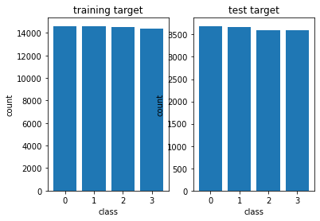

```python
bars = ('0', '1', '2', '3')
plt.subplot(1,2,1)
plt.bar(bars, pd.value_counts(y_train))
plt.xlabel('class')
plt.ylabel('count')
plt.title('training target')
plt.subplot(1,2,2)
plt.bar(bars, pd.value_counts(y_test))
plt.xlabel('class')
plt.ylabel('count')
plt.title('test target')
```

## Pre-processing and Initial Modeling (2.5 points total)

You will be using a two layer perceptron from class for the next few parts of the rubric. There are several versions of the two layer perceptron covered in class, with example code. When selecting an example two layer network from class be sure that you use: (1) vectorized gradient computation, (2) mini-batching, (3) cross entropy loss, and (4) proper Glorot initialization, at a minimum. There is no need to use momentum or learning rate reduction (assuming you choose a sufficiently small learning rate). It is recommended to use sigmoids throughout the network, but not required.

```python
#Example adapted from https://github.com/rasbt/python-machine-learning-book/blob/master/code/ch12/ch12.ipynb
#Original Author: Sebastian Raschka

import numpy as np
from scipy.special import expit
import sys
import pandas as pd

# start with a simple base classifier, which can't be fit or predicted
# it only has internal classes to be used by classes that will subclass it
# Start with the following functions:
#    init
#    encode_labels
#    initialize weights
#    sigmoid
#    add bias (vector of ones)
#    objective function (cost and regularizer)
class TwoLayerPerceptronBase(object):
    def __init__(self, n_hidden=30,
                 C=0.0, epochs=500, eta=0.001, random_state=None):
        np.random.seed(random_state)
        self.n_hidden = n_hidden
        self.l2_C = C
        self.epochs = epochs
        self.eta = eta

    @staticmethod
    def _encode_labels(y):
        """Encode labels into one-hot representation"""
        onehot = pd.get_dummies(y).values.T

        return onehot
#     def _encode_labels(y):
#         """Encode labels as integers from 0 to n_classes-1"""
#         labels = np.unique(y)
#         label_dict = {label: i for i, label in enumerate(labels)}
#         y_enc = np.array([label_dict[label] for label in y], dtype=int)
#         return y_enc

    def _initialize_weights(self):
        """Initialize weights with small random numbers."""
        W1_num_elems = (self.n_features_ + 1)*self.n_hidden
        W1 = np.random.uniform(-1.0, 1.0, size=W1_num_elems)
        W1 = W1.reshape(self.n_hidden, self.n_features_ + 1) # reshape to be W

        W2_num_elems = (self.n_hidden + 1)*self.n_output_
        W2 = np.random.uniform(-1.0, 1.0, size=W2_num_elems)
        W2 = W2.reshape(self.n_output_, self.n_hidden + 1)
        return W1, W2

    @staticmethod
    def _sigmoid(z):
        """Use scipy.special.expit to avoid overflow"""
        # 1.0 / (1.0 + np.exp(-z))
        return expit(z)

    @staticmethod
    def _add_bias_unit(X, how='column'):
        """Add bias unit (column or row of 1s) to array at index 0"""
        if how == 'column':
            ones = np.ones((X.shape[0], 1))
            X_new = np.hstack((ones, X))
        elif how == 'row':
            ones = np.ones((1, X.shape[1]))
            X_new = np.vstack((ones, X))
        return X_new

    @staticmethod
    def _L2_reg(lambda_, W1, W2):
        """Compute L2-regularization cost"""
        # only compute for non-bias terms
        return (lambda_) * np.sqrt(np.mean(W1[:, 1:] ** 2) + np.mean(W2[:, 1:] ** 2))

    def _cost(self,A3,Y_enc,W1,W2):
        '''Get the objective function value'''
        cost = np.mean((Y_enc-A3)**2)
        L2_term = self._L2_reg(self.l2_C, W1, W2)
        return cost + L2_term
```

```python
# now let's add in the following functions:
#    feedforward
#    fit and predict
class TwoLayerPerceptron(TwoLayerPerceptronBase):
    def _feedforward(self, X, W1, W2):
        """Compute feedforward step
        -----------
        X : Input layer with original features.
        W1: Weight matrix for input layer -> hidden layer.
        W2: Weight matrix for hidden layer -> output layer.
        ----------
        a1-a3 : activations into layer (or output layer)
        z1-z2 : layer inputs

        """
        A1 = self._add_bias_unit(X.T, how='row')
        Z1 = W1 @ A1
        A2 = self._sigmoid(Z1)
        A2 = self._add_bias_unit(A2, how='row')
        Z2 = W2 @ A2
        A3 = self._sigmoid(Z2)
        return A1, Z1, A2, Z2, A3

    def _get_gradient(self, A1, A2, A3, Z1, Z2, Y_enc, W1, W2):
        """ Compute gradient step using backpropagation.
        """
        # need to vectorize this computation!
        # See additional code and derivation below!

    def predict(self, X):
        """Predict class labels"""
        _, _, _, _, A3 = self._feedforward(X, self.W1, self.W2)
        y_pred = np.argmax(A3, axis=0)
        return y_pred


    def fit(self, X, y, print_progress=False):
        """ Learn weights from training data."""

        X_data, y_data = X.copy(), y.copy()
        Y_enc = self._encode_labels(y)

        # init weights and setup matrices
        self.n_features_ = X_data.shape[1]
        self.n_output_ = Y_enc.shape[0]
        self.W1, self.W2 = self._initialize_weights()

        self.cost_ = []
        for i in range(self.epochs):

            if print_progress>0 and (i+1)%print_progress==0:
                sys.stderr.write('\rEpoch: %d/%d' % (i+1, self.epochs))
                sys.stderr.flush()

            # feedforward all instances
            A1, Z1, A2, Z2, A3 = self._feedforward(X_data,self.W1,self.W2)

            cost = self._cost(A3,Y_enc,self.W1,self.W2)
            self.cost_.append(cost)

            # compute gradient via backpropagation
            grad1, grad2 = self._get_gradient(A1=A1, A2=A2, A3=A3, Z1=Z1, Z2=Z2, Y_enc=Y_enc,
                                              W1=self.W1, W2=self.W2)

            self.W1 -= self.eta * grad1
            self.W2 -= self.eta * grad2


        return self
```

(1) vectorized gradient computation

```python
class TwoLayerPerceptronVectorized(TwoLayerPerceptron):
    # just need a different gradient calculation
    def _get_gradient(self, A1, A2, A3, Z1, Z2, Y_enc, W1, W2):
        """ Compute gradient step using backpropagation.
        """
        # vectorized backpropagation
        V2 = -2*(Y_enc-A3)*A3*(1-A3)
        V1 = A2*(1-A2)*(W2.T @ V2)

        grad2 = V2 @ A2.T
        grad1 = V1[1:,:] @ A1.T


        # regularize weights that are not bias terms
        grad1[:, 1:] += W1[:, 1:] * self.l2_C
        grad2[:, 1:] += W2[:, 1:] * self.l2_C

        return grad1, grad2
```

```python
params = dict(n_hidden=50,
              C=0.001, # tradeoff L2 regularizer
              epochs=200, # iterations
              eta=0.001,  # learning rate
              random_state=1)
```

```python
%%time
nn = TwoLayerPerceptronVectorized(**params)

nn.fit(X_train, y_train, print_progress=50)
yhat = nn.predict(X_test)
print('Accuracy:',accuracy_score(y_test,yhat))
```

```
Epoch: 200/200
```

```
Accuracy: 0.25165016501650167
Wall time: 1min 12s
```

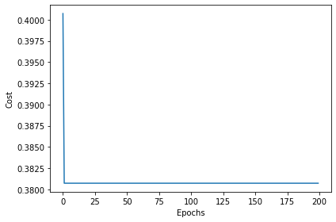

```python
plt.plot(range(len(nn.cost_)), nn.cost_)
plt.ylabel('Cost')
plt.xlabel('Epochs')
plt.tight_layout()
plt.show()
```

```python
params = dict(n_hidden=50,
              C=1, # tradeoff L2 regularizer
              epochs=500, # iterations
              eta=0.01,  # learning rate
              random_state=1)
```

```python
%%time
nn = TwoLayerPerceptronVectorized(**params)

nn.fit(X_train, y_train, print_progress=50)
yhat = nn.predict(X_test)
print('Accuracy:',accuracy_score(y_test,yhat))
```

```
Epoch: 500/500
```

```
Accuracy: 0.25165016501650167
Wall time: 2min 50s
```

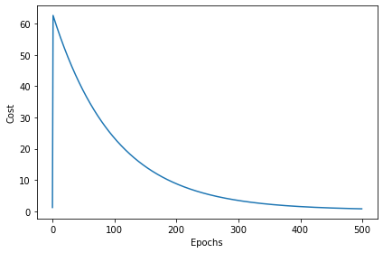

```python
plt.plot(range(len(nn.cost_)), nn.cost_)
plt.ylabel('Cost')
plt.xlabel('Epochs')
plt.tight_layout()
plt.show()
```

(2) mini-batching

```python
# Example adapted from https://github.com/rasbt/python-machine-learning-book/blob/master/code/ch12/ch12.ipynb
# Original Author: Sebastian Raschka
# This is the optional book we use in the course, excellent intuitions and straightforward programming examples
# please note, however, that this code has been manipulated to reflect our assumptions and notation.
class TLPVectorizedMiniBatch(TwoLayerPerceptronVectorized):
    def __init__(self, alpha=0.1, decrease_const=0.0, shuffle=True, minibatches=1, **kwds):
        # need to add to the original initializer
        self.alpha = alpha
        self.decrease_const = decrease_const
        self.shuffle = shuffle
        self.minibatches = minibatches
        # but keep other keywords
        super().__init__(**kwds)

    def fit(self, X, y, print_progress=0):
        """ Learn weights from training data."""
        X_data, y_data = X.copy(), y.copy()
        Y_enc = self._encode_labels(y)

        # init weights and setup matrices
        self.n_features_ = X_data.shape[1]
        self.n_output_ = Y_enc.shape[0]
        self.W1, self.W2 = self._initialize_weights()

        # start momentum at zero for previous updates
        rho_W1_prev = np.zeros(self.W1.shape) # for momentum
        rho_W2_prev = np.zeros(self.W2.shape) # for momentum

        self.cost_ = []
        for k in range(self.epochs):

            # adaptive learning rate
            eta = self.eta**(1+self.decrease_const*k)# decreasing learning rate
            eta = max(eta,self.eta/1000)
            # there are many forms of adaptive learning rates out there!

            if print_progress>0 and (k+1)%print_progress==0:
                sys.stderr.write('\rEpoch: %d/%d' % (k+1, self.epochs))
                sys.stderr.flush()

            if self.shuffle:
                ridx = np.random.permutation(y_data.shape[0])

#                 X_data=X_data.iloc[ridx]
#                 print(X_data)
#                 Y_enc = Y_enc[:, ridx]
#                 print(Y_enc)
                X_data, Y_enc = X_data.iloc[ridx], Y_enc[:, ridx]

            # use numpy split to split into equal sized batches
            # num batches== self.minibatches
            mini = np.array_split(range(y_data.shape[0]), self.minibatches)
            mini_cost = []
            for idx in mini:

                # feedforward
                A1, Z1, A2, Z2, A3 = self._feedforward(X_data.iloc[idx],
                                                       self.W1,
                                                       self.W2)

                cost = self._cost(A3,Y_enc[:, idx],self.W1,self.W2)
                mini_cost.append(cost) # this appends cost of mini-batch only

                # compute gradient via backpropagation
                grad1, grad2 = self._get_gradient(A1=A1, A2=A2, A3=A3, Z1=Z1, Z2=Z2,
                                                  Y_enc=Y_enc[:, idx],
                                                  W1=self.W1, W2=self.W2)

                rho_W1, rho_W2 = eta * grad1, eta * grad2
                self.W1 -= (rho_W1 + (self.alpha * rho_W1_prev)) # update with momentum
                self.W2 -= (rho_W2 + (self.alpha * rho_W2_prev)) # update with momentum
                rho_W1_prev, rho_W2_prev = rho_W1, rho_W2

            self.cost_.append(mini_cost)

        return self
```

```python
%%time
nn_mini = TLPVectorizedMiniBatch(
                          n_hidden=50,
                          C=0.001,
                          epochs=50,
                          eta=0.001,
                          alpha=0.05,
                          decrease_const=0.1,
                          minibatches=len(X_train)/256,
                          shuffle=True,
                          random_state=1)

nn_mini.fit(X_train, y_train, print_progress=1)
yhat = nn_mini.predict(X_test)
print('Validation acc:',accuracy_score(y_test,yhat))
```

```
Epoch: 50/50
```

```
Validation acc: 0.2484185918591859
Wall time: 31.4 s
```

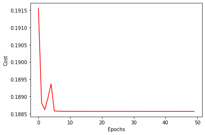

```python
# take the mean of each minibatch epoch
cost_avgs = [np.mean(x) for x in nn_mini.cost_]

plt.plot(range(len(cost_avgs)), cost_avgs, color='red')
plt.ylabel('Cost')
plt.xlabel('Epochs')
plt.tight_layout()
plt.show()
```

```python
%%time
params['epochs'] = 100
params['eta'] = 0.001
nn_mini = TLPVectorizedMiniBatch(**params,
                          alpha=0.1,# momentum calculation
                          decrease_const=0.1, # decreasing eta
                          minibatches=len(X_train)/32, # minibatch size
                          shuffle=True)


nn_mini.fit(X_train, y_train, print_progress=50)
yhat = nn.predict(X_test)
print('Accuracy:',accuracy_score(y_test,yhat))
```

```
Epoch: 100/100
```

```
Accuracy: 0.25165016501650167
Wall time: 3min 34s
```

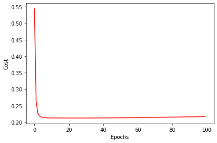

```python
# take the mean of each minibatch epoch
cost_avgs = [np.mean(x) for x in nn_mini.cost_]

plt.plot(range(len(cost_avgs)), cost_avgs, color='red')
plt.ylabel('Cost')
plt.xlabel('Epochs')
plt.tight_layout()
plt.show()
```

(3) cross entropy loss

```python
class TwoLayerPerceptronBase(object):
    def __init__(self, n_hidden=30,
                 C=0.0, epochs=500, eta=0.001, random_state=None):
        np.random.seed(random_state)
        self.n_hidden = n_hidden
        self.l2_C = C
        self.epochs = epochs
        self.eta = eta

    @staticmethod
    def _encode_labels(y):
        """Encode labels into one-hot representation"""
        onehot = pd.get_dummies(y).values.T

        return onehot

    def _initialize_weights(self):
        """Initialize weights with small random numbers."""
        W1_num_elems = (self.n_features_ + 1)*self.n_hidden
        W1 = np.random.uniform(-1.0, 1.0,size=W1_num_elems)
        W1 = W1.reshape(self.n_hidden, self.n_features_ + 1) # reshape to be W

        W2_num_elems = (self.n_hidden + 1)*self.n_output_
        W2 = np.random.uniform(-1.0, 1.0, size=W2_num_elems)
        W2 = W2.reshape(self.n_output_, self.n_hidden + 1)
        return W1, W2

    @staticmethod
    def _sigmoid(z):
        """Use scipy.special.expit to avoid overflow"""
        # 1.0 / (1.0 + np.exp(-z))
        return expit(z)

    @staticmethod
    def _add_bias_unit(X, how='column'):
        """Add bias unit (column or row of 1s) to array at index 0"""
        if how == 'column':
            ones = np.ones((X.shape[0], 1))
            X_new = np.hstack((ones, X))
        elif how == 'row':
            ones = np.ones((1, X.shape[1]))
            X_new = np.vstack((ones, X))
        return X_new

    @staticmethod
    def _L2_reg(lambda_, W1, W2):
        """Compute L2-regularization cost"""
        # only compute for non-bias terms
        return (lambda_/2.0) * np.sqrt(np.mean(W1[:, 1:] ** 2) + np.mean(W2[:, 1:] ** 2))

    def _cost(self,A3,Y_enc,W1,W2):
        '''Get the objective function value'''
        cost = np.mean((Y_enc-A3)**2)
        L2_term = self._L2_reg(self.l2_C, W1, W2)
        return cost + L2_term

    def _feedforward(self, X, W1, W2):
        """Compute feedforward step
        """
        A1 = self._add_bias_unit(X, how='column')
        A1 = A1.T
        Z1 = W1 @ A1
        A2 = self._sigmoid(Z1)
        A2 = self._add_bias_unit(A2, how='row')
        Z2 = W2 @ A2
        A3 = self._sigmoid(Z2)
        return A1, Z1, A2, Z2, A3

    def _get_gradient(self, A1, A2, A3, Z1, Z2, Y_enc, W1, W2):
        """ Compute gradient step using backpropagation.
        """
        # vectorized backpropagation
        V2 = -2*(Y_enc-A3)*A3*(1-A3)  # last layer sensitivity
        V1 = A2*(1-A2)*(W2.T @ V2) # back prop the sensitivity

        grad2 = V2 @ A2.T # no bias on final layer
        grad1 = V1[1:,:] @ A1.T # dont back prop sensitivity of bias


        # regularize weights that are not bias terms
        grad1[:, 1:] += W1[:, 1:] * self.l2_C
        grad2[:, 1:] += W2[:, 1:] * self.l2_C

        return grad1, grad2

    def predict(self, X):
        """Predict class labels"""
        _, _, _, _, A3 = self._feedforward(X, self.W1, self.W2)
        y_pred = np.argmax(A3, axis=0)
        return y_pred
```

```python
from sklearn.metrics import accuracy_score
# just start with the vectorized version and minibatch
class TLPMiniBatch(TwoLayerPerceptronBase):
    def __init__(self, alpha=0.0, decrease_const=0.0, shuffle=True,
                 minibatches=1, **kwds):
        # need to add to the original initializer
        self.alpha = alpha
        self.decrease_const = decrease_const
        self.shuffle = shuffle
        self.minibatches = minibatches
        # but keep other keywords
        super().__init__(**kwds)


    def fit(self, X, y, print_progress=False, XY_test=None):
        """ Learn weights from training data. With mini-batch"""
        X_data, y_data = X.copy(), y.copy()
        Y_enc = self._encode_labels(y)

        # init weights and setup matrices
        self.n_features_ = X_data.shape[1]
        self.n_output_ = Y_enc.shape[0]
        self.W1, self.W2 = self._initialize_weights()

        rho_W1_prev = np.zeros(self.W1.shape)
        rho_W2_prev = np.zeros(self.W2.shape)

        self.cost_ = []
        self.score_ = []
        # get starting acc
        self.score_.append(accuracy_score(y_data,self.predict(X_data)))
        # keep track of validation, if given
        if XY_test is not None:
            X_test = XY_test[0].copy()
            y_test = XY_test[1].copy()
            self.val_score_ = []
            self.val_score_.append(accuracy_score(y_test,self.predict(X_test)))

        for i in range(self.epochs):

            # adaptive learning rate
            # \frac{\eta}{1+\epsilon\cdot k}
            eta = self.eta / (1 + self.decrease_const*i)

            if print_progress>0 and (i+1)%print_progress==0:
                sys.stderr.write('\rEpoch: %d/%d' % (i+1, self.epochs))
                sys.stderr.flush()

            if self.shuffle:
                idx_shuffle = np.random.permutation(y_data.shape[0])
                X_data, Y_enc, y_data = X_data.iloc[idx_shuffle], Y_enc[:, idx_shuffle], y_data[idx_shuffle]

            mini = np.array_split(range(y_data.shape[0]), self.minibatches)
            mini_cost = []
            for idx in mini:

                # feedforward
                A1, Z1, A2, Z2, A3 = self._feedforward(X_data.iloc[idx],
                                                       self.W1,
                                                       self.W2)

                cost = self._cost(A3,Y_enc[:, idx],self.W1,self.W2)
                mini_cost.append(cost) # this appends cost of mini-batch only

                # compute gradient via backpropagation
                grad1, grad2 = self._get_gradient(A1=A1, A2=A2, A3=A3, Z1=Z1, Z2=Z2,
                                                  Y_enc=Y_enc[:, idx],
                                                  W1=self.W1,W2=self.W2)

                # momentum calculations
                rho_W1, rho_W2 = eta * grad1, eta * grad2
                self.W1 -= (rho_W1 + (self.alpha * rho_W1_prev))
                self.W2 -= (rho_W2 + (self.alpha * rho_W2_prev))
                rho_W1_prev, rho_W2_prev = rho_W1, rho_W2

            self.cost_.append(mini_cost)
            self.score_.append(accuracy_score(y_data,self.predict(X_data)))
            if XY_test is not None:
                self.val_score_.append(accuracy_score(y_test,self.predict(X_test)))

        return self
```

```python
# to implement the new style of objective function,
# we just need to update the final layer calculation of the gradient
class TLPMiniBatchCrossEntropy(TLPMiniBatch):
    def _cost(self,A3,Y_enc,W1,W2):
        '''Get the objective function value'''
        cost = -np.mean(np.nan_to_num((Y_enc*np.log(A3)+(1-Y_enc)*np.log(1-A3))))
        L2_term = self._L2_reg(self.l2_C, W1, W2)
        return cost + L2_term

    def _get_gradient(self, A1, A2, A3, Z1, Z2, Y_enc, W1, W2):
        """ Compute gradient step using backpropagation.
        """
        # vectorized backpropagation
        V2 = (A3-Y_enc) # <- this is only line that changed
        V1 = A2*(1-A2)*(W2.T @ V2)

        grad2 = V2 @ A2.T
        grad1 = V1[1:,:] @ A1.T

        # regularize weights that are not bias terms
        grad1[:, 1:] += W1[:, 1:] * self.l2_C
        grad2[:, 1:] += W2[:, 1:] * self.l2_C

        return grad1, grad2
```

```python
vals = { 'n_hidden':30,
         'C':0.001, 'epochs':20, 'eta':0.001,
         'alpha':0.001, 'decrease_const':0, 'minibatches':100,
         'shuffle':True,'random_state':1}


nn_cross = TLPMiniBatchCrossEntropy(**vals)

%time nn_cross.fit(X_train, y_train, print_progress=1, XY_test=(X_test, y_test))

print("Done")
```

```
Epoch: 20/20
```

```
Wall time: 11.6 s
Done
```

```python
%matplotlib inline

plt.style.use('ggplot')

def print_result(nn,X_train,y_train,X_test,y_test,title="",color="red"):

    print("=================")
    print(title,":")
    yhat = nn.predict(X_train)
    print('Resubstitution acc:',accuracy_score(y_train,yhat))

    yhat = nn.predict(X_test)
    print('Validation acc:',accuracy_score(y_test,yhat))

    if hasattr(nn,'val_score_'):
        plt.plot(range(len(nn.val_score_)), nn.val_score_, color=color,label=title)
        plt.ylabel('Validation Accuracy')
    else:
        plt.plot(range(len(nn.score_)), nn.score_, color=color,label=title)
        plt.ylabel('Resub Accuracy')

    plt.xlabel('Epochs')
    plt.tight_layout()
    plt.legend(loc='best')
    plt.grid(True)
```

```
=================
Cross Entropy Loss :
Resubstitution acc: 0.2502836318630316
Validation acc: 0.25027502750275027
```

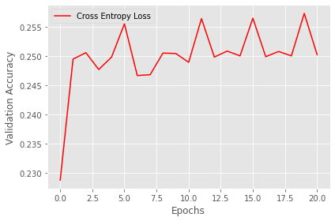

```python
print_result(nn_cross,X_train,y_train,X_test,y_test,title="Cross Entropy Loss",color="red")


plt.show()
```

(4) proper Glorot initialization, at a minimum. There is no need to use momentum or learning rate reduction (assuming you choose a sufficiently small learning rate). It is recommended to use sigmoids throughout the network, but not required.

```python
class TLPBetterInitial(TLPMiniBatchCrossEntropy):
    def _initialize_weights(self):
        """Initialize weights Glorot and He normalization."""
        init_bound = 4*np.sqrt(6. / (self.n_hidden + self.n_features_ + 1))
        W1 = np.random.uniform(-init_bound, init_bound,(self.n_hidden, self.n_features_ + 1))
        W1[:,:1] = 0

        # reduce the final layer magnitude in order to balance the size of the gradients
        # between
        init_bound = 4*np.sqrt(6 / (self.n_output_ + self.n_hidden + 1))
        W2 = np.random.uniform(-init_bound, init_bound,(self.n_output_, self.n_hidden + 1))
        W2[:,:1] = 0

        return W1, W2
```

```
Epoch: 10/10
```

```
Wall time: 5.99 s
```

```
Epoch: 10/10
```

```
Wall time: 5.63 s
=================
Traditional :
Resubstitution acc: 0.25325746897239315
Validation acc: 0.24896864686468648
=================
Glorot Initial :
Resubstitution acc: 0.25138377969539655
Validation acc: 0.24724972497249725
```

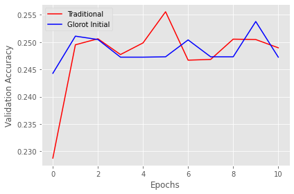

```python
vals['epochs'] = 10

nn_tradit = TLPMiniBatchCrossEntropy(**vals)
nn_better = TLPBetterInitial(**vals)

%time nn_tradit.fit(X_train, y_train, print_progress=1, XY_test=(X_test, y_test))
%time nn_better.fit(X_train, y_train, print_progress=1, XY_test=(X_test, y_test))

print_result(nn_tradit,X_train,y_train,X_test,y_test,title="Traditional",color="red")
print_result(nn_better,X_train,y_train,X_test,y_test,title="Glorot Initial",color="blue")
plt.show()
```

```
Epoch: 50/50
```

```
Wall time: 32.7 s
=================
Long Run :
Resubstitution acc: 0.2510571733076632
Validation acc: 0.25165016501650167
```

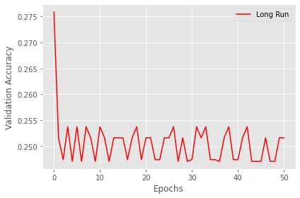

```python
# just for fun, let's look at the output of what happens when we let our system loose
# these values have been hand tuned
vals = {'n_hidden':50,
         'C':1, 'epochs':50, 'eta':0.01,
         'alpha':0.1, 'decrease_const':0.1, 'minibatches':len(X_train)/256,
         'shuffle':True,'random_state':1}

nn_long_sigmoid = TLPBetterInitial(**vals)

%time nn_long_sigmoid.fit(X_train, y_train, print_progress=1, XY_test=(X_test,y_test))
print_result(nn_long_sigmoid,X_train,y_train,X_test,y_test,title="Long Run",color="red")
```

Use the example two-layer perceptron network from the class example and quantify performance using accuracy. Do not normalize or one-hot encode the data (not yet). Be sure that training converges by graphing the loss function versus the number of epochs.

```python
# start with a simple base classifier, which can't be fit or predicted
# it only has internal classes to be used by classes that will subclass it
class TwoLayerPerceptronBase(object):
    def __init__(self, n_hidden=30,
                 C=0.0, epochs=500, eta=0.001, random_state=None):
        np.random.seed(random_state)
        self.n_hidden = n_hidden
        self.l2_C = C
        self.epochs = epochs
        self.eta = eta

    @staticmethod
    def _encode_labels(y):
        """Encode labels into one-hot representation"""
        onehot = pd.get_dummies(y).values.T

        return onehot

    def _initialize_weights(self):
        """Initialize weights with small random numbers."""
        W1_num_elems = (self.n_features_ + 1)*self.n_hidden
        W1 = np.random.uniform(-1.0, 1.0,size=W1_num_elems)
        W1 = W1.reshape(self.n_hidden, self.n_features_ + 1) # reshape to be W

        W2_num_elems = (self.n_hidden + 1)*self.n_output_
        W2 = np.random.uniform(-1.0, 1.0, size=W2_num_elems)
        W2 = W2.reshape(self.n_output_, self.n_hidden + 1)
        return W1, W2

    @staticmethod
    def _sigmoid(z):
        """Use scipy.special.expit to avoid overflow"""
        # 1.0 / (1.0 + np.exp(-z))
        return expit(z)

    @staticmethod
    def _add_bias_unit(X, how='column'):
        """Add bias unit (column or row of 1s) to array at index 0"""
        if how == 'column':
            ones = np.ones((X.shape[0], 1))
            X_new = np.hstack((ones, X))
        elif how == 'row':
            ones = np.ones((1, X.shape[1]))
            X_new = np.vstack((ones, X))
        return X_new

    @staticmethod
    def _L2_reg(lambda_, W1, W2):
        """Compute L2-regularization cost"""
        # only compute for non-bias terms
        return (lambda_/2.0) * np.sqrt(np.mean(W1[:, 1:] ** 2) + np.mean(W2[:, 1:] ** 2))

    def _cost(self,A3,Y_enc,W1,W2):
        '''Get the objective function value'''
        cost = np.mean((Y_enc-A3)**2)
        L2_term = self._L2_reg(self.l2_C, W1, W2)
        return cost + L2_term

    def _feedforward(self, X, W1, W2):
        """Compute feedforward step
        """
        A1 = self._add_bias_unit(X, how='column')
        A1 = A1.T
        Z1 = W1 @ A1
        A2 = self._sigmoid(Z1)
        A2 = self._add_bias_unit(A2, how='row')
        Z2 = W2 @ A2
        A3 = self._sigmoid(Z2)
        return A1, Z1, A2, Z2, A3

    def _get_gradient(self, A1, A2, A3, Z1, Z2, Y_enc, W1, W2):
        """ Compute gradient step using backpropagation.
        """
        # vectorized backpropagation
        V2 = -2*(Y_enc-A3)*A3*(1-A3)  # last layer sensitivity
        V1 = A2*(1-A2)*(W2.T @ V2) # back prop the sensitivity

        grad2 = V2 @ A2.T # no bias on final layer
        grad1 = V1[1:,:] @ A1.T # dont back prop sensitivity of bias


        # regularize weights that are not bias terms
        grad1[:, 1:] += W1[:, 1:] * self.l2_C
        grad2[:, 1:] += W2[:, 1:] * self.l2_C

        return grad1, grad2

    def predict(self, X):
        """Predict class labels"""
        _, _, _, _, A3 = self._feedforward(X, self.W1, self.W2)
        y_pred = np.argmax(A3, axis=0)
        return y_pred
```

```python
class TLPMiniBatch(TwoLayerPerceptronBase):
    def __init__(self, alpha=0.0, decrease_const=0.0, shuffle=True,
                 minibatches=1, **kwds):
        # need to add to the original initializer
        self.alpha = alpha
        self.decrease_const = decrease_const
        self.shuffle = shuffle
        self.minibatches = minibatches
        # but keep other keywords
        super().__init__(**kwds)


    def fit(self, X, y, print_progress=False, XY_test=None):
        """ Learn weights from training data. With mini-batch"""
        X_data, y_data = X.copy(), y.copy()
        Y_enc = self._encode_labels(y)

        # init weights and setup matrices
        self.n_features_ = X_data.shape[1]
        self.n_output_ = Y_enc.shape[0]
        self.W1, self.W2 = self._initialize_weights()

        rho_W1_prev = np.zeros(self.W1.shape)
        rho_W2_prev = np.zeros(self.W2.shape)

        self.cost_ = []
        self.score_ = []
        # get starting acc
        self.score_.append(accuracy_score(y_data,self.predict(X_data)))
        # keep track of validation, if given
        if XY_test is not None:
            X_test = XY_test[0].copy()
            y_test = XY_test[1].copy()
            self.val_score_ = []
            self.val_score_.append(accuracy_score(y_test,self.predict(X_test)))

        for i in range(self.epochs):

            # adaptive learning rate
            # \frac{\eta}{1+\epsilon\cdot k}
            eta = self.eta / (1 + self.decrease_const*i)

            if print_progress>0 and (i+1)%print_progress==0:
                sys.stderr.write('\rEpoch: %d/%d' % (i+1, self.epochs))
                sys.stderr.flush()

            if self.shuffle:
                idx_shuffle = np.random.permutation(y_data.shape[0])
                X_data, Y_enc, y_data = X_data.iloc[idx_shuffle], Y_enc[:, idx_shuffle], y_data[idx_shuffle]

            mini = np.array_split(range(y_data.shape[0]), self.minibatches)
            mini_cost = []
            for idx in mini:

                # feedforward
                A1, Z1, A2, Z2, A3 = self._feedforward(X_data.iloc[idx],
                                                       self.W1,
                                                       self.W2)

                cost = self._cost(A3,Y_enc[:, idx],self.W1,self.W2)
                mini_cost.append(cost) # this appends cost of mini-batch only

                # compute gradient via backpropagation
                grad1, grad2 = self._get_gradient(A1=A1, A2=A2, A3=A3, Z1=Z1, Z2=Z2,
                                                  Y_enc=Y_enc[:, idx],
                                                  W1=self.W1,W2=self.W2)

                # momentum calculations
                rho_W1, rho_W2 = eta * grad1, eta * grad2
                self.W1 -= (rho_W1 + (self.alpha * rho_W1_prev))
                self.W2 -= (rho_W2 + (self.alpha * rho_W2_prev))
                rho_W1_prev, rho_W2_prev = rho_W1, rho_W2

            self.cost_.append(mini_cost)
            self.score_.append(accuracy_score(y_data,self.predict(X_data)))
            if XY_test is not None:
                self.val_score_.append(accuracy_score(y_test,self.predict(X_test)))

        return self
```

```python
vals = { 'n_hidden':30,
         'C':1, 'epochs':50, 'eta':0.001,
         'alpha':0.1, 'decrease_const':10, 'minibatches':50,
         'shuffle':True,'random_state':1}

nn_quad = TLPMiniBatch(**vals)

%time nn_quad.fit(X_train, y_train, print_progress=1, XY_test=(X_test, y_test))
print("Done")
```

```
Epoch: 50/50
```

```
Wall time: 25.1 s
Done
```

```
=================
MSE Loss :
Resubstitution acc: 0.25129783064599304
Validation acc: 0.2473872387238724
```

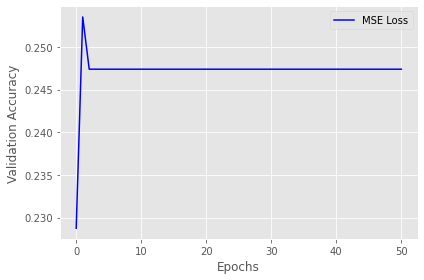

```python
print_result(nn_quad,X_train,y_train,X_test,y_test,title="MSE Loss",color="blue")

plt.show()
```

[.5 points] Now (1) normalize the continuous numeric feature data. Use the example two-layer perceptron network from the class example and quantify performance using accuracy. Be sure that training converges by graphing the loss function versus the number of epochs.

```python
X_train1=X_train.drop(['State'],axis=1)
X_train_normalized=(X_train1-X_train1.mean())/X_train1.std()
X_train_normalized.insert(0, "State", X_train['State'])
X_train_normalized
```

|  | State | TotalPop | Men | Women | Hispanic | White | Black | Native | Asian | Pacific | ... | Walk | OtherTransp | WorkAtHome | MeanCommute | Employed | PrivateWork | PublicWork | SelfEmployed | FamilyWork | Unemployment |
| --- | --- | --- | --- | --- | --- | --- | --- | --- | --- | --- | --- | --- | --- | --- | --- | --- | --- | --- | --- | --- | --- |
| 0 | 0 | -0.466038 | -0.397821 | -0.518207 | -0.564150 | 1.003431 | -0.606093 | -0.071673 | -0.274371 | -0.149174 | ... | -0.501188 | -0.635951 | -0.111578 | 0.664958 | -0.528329 | -0.265734 | 0.579261 | -0.518109 | -0.156330 | 0.113351 |
| 1 | 21 | -0.933023 | -1.053268 | -0.785997 | -0.737588 | 1.036118 | -0.615392 | -0.161634 | 0.200555 | -0.149174 | ... | 0.564629 | -0.238036 | 2.467489 | -0.083191 | -0.974504 | -2.213094 | 0.383961 | 3.934682 | -0.376686 | -1.186401 |
| 2 | 32 | -0.896819 | -0.912880 | -0.852944 | -0.061180 | 0.114330 | -0.252718 | -0.161634 | 0.145331 | -0.149174 | ... | 0.374304 | -0.078870 | -0.616756 | 2.612967 | -0.891912 | -1.396459 | 2.127705 | -1.045066 | -0.376686 | -0.103274 |
| 3 | 9 | 3.172228 | 3.110962 | 3.132654 | 0.446126 | -0.153708 | -0.178323 | -0.161634 | -0.108699 | -0.149174 | ... | -0.348928 | -0.516576 | 0.260659 | 1.229598 | 3.190100 | 0.475519 | -0.355386 | -0.280978 | -0.376686 | 0.172431 |
| 4 | 20 | 0.934000 | 0.754453 | 1.080495 | -0.303993 | -0.009883 | 0.212249 | -0.161634 | 0.311003 | -0.149174 | ... | -0.444090 | -0.556368 | 0.925366 | 1.257830 | 0.887403 | -1.308514 | 1.402308 | 0.140588 | -0.376686 | -0.063888 |
| ... | ... | ... | ... | ... | ... | ... | ... | ... | ... | ... | ... | ... | ... | ... | ... | ... | ... | ... | ... | ... | ... |
| 58169 | 4 | 1.349658 | 1.257661 | 1.397379 | 0.129602 | -1.415447 | 0.328491 | 0.040778 | 3.458768 | 0.162702 | ... | -0.463123 | -0.118661 | -0.510402 | 0.707306 | 1.493376 | 0.111174 | 0.132862 | -0.412717 | -0.376686 | -0.182047 |
| 58170 | 32 | -1.063174 | -1.104318 | -0.989517 | -0.139227 | 0.356218 | -0.280616 | -0.161634 | 0.045928 | -0.149174 | ... | 0.831083 | -0.755326 | 0.632895 | 1.300178 | -0.877549 | -0.680333 | 1.039609 | -0.491761 | -0.376686 | -0.418365 |
| 58171 | 4 | -0.270812 | -0.184504 | -0.346822 | 1.330660 | -1.905760 | -0.517749 | 0.355642 | 4.342352 | -0.045215 | ... | -0.501188 | -0.158453 | -0.005225 | 0.396754 | -0.156665 | 0.060919 | -0.229837 | -0.122891 | 3.589731 | 0.389056 |
| 58172 | 2 | 0.353363 | 0.375224 | 0.320866 | 1.157222 | -1.402372 | -0.615392 | 7.372614 | -0.451088 | 0.474578 | ... | 0.222045 | -0.158453 | -0.324284 | -1.678300 | -0.069585 | -3.079983 | 3.341351 | 0.193284 | -0.376686 | 1.019239 |
| 58173 | 6 | -0.628726 | -0.817161 | -0.424481 | -0.191258 | -0.091602 | 0.430784 | -0.139144 | -0.252281 | -0.149174 | ... | 2.087223 | -0.755326 | 7.545857 | -0.647831 | -1.259087 | -0.215480 | 1.123309 | -1.624720 | -0.376686 | 0.408749 |

58174 rows × 34 columns

```python
X_test1=X_test.drop(['State'],axis=1)
X_test_normalized=(X_test1-X_test1.mean())/X_test1.std()
X_test_normalized.insert(0, "State", X_test['State'])
X_test_normalized
```

|  | State | TotalPop | Men | Women | Hispanic | White | Black | Native | Asian | Pacific | ... | Walk | OtherTransp | WorkAtHome | MeanCommute | Employed | PrivateWork | PublicWork | SelfEmployed | FamilyWork | Unemployment |
| --- | --- | --- | --- | --- | --- | --- | --- | --- | --- | --- | --- | --- | --- | --- | --- | --- | --- | --- | --- | --- | --- |
| 0 | 22 | -0.057909 | -0.002012 | -0.110756 | -0.693592 | 0.611762 | -0.111139 | -0.076886 | -0.288414 | -0.129827 | ... | -0.131575 | -0.395093 | -0.967295 | 0.399858 | -0.345547 | 0.591433 | -0.245748 | -0.727323 | -0.389282 | 1.769222 |
| 1 | 35 | -0.130806 | -0.050580 | -0.205348 | -0.559801 | 0.267266 | -0.006005 | -0.161345 | -0.311253 | -0.129827 | ... | 0.190008 | -0.774360 | -0.731025 | -0.566296 | -0.156829 | 0.893357 | -0.763213 | -0.412537 | -0.389282 | 1.055599 |
| 2 | 46 | 0.034337 | 0.301987 | -0.227244 | -0.684961 | 0.956257 | -0.303123 | -0.161345 | -0.459707 | -0.129827 | ... | -0.547741 | -0.100108 | 0.870354 | -0.370265 | -0.327199 | 0.465631 | -0.203791 | -0.517466 | -0.389282 | -0.873114 |
| 3 | 43 | 2.708132 | 4.731559 | 0.663495 | 0.130736 | -1.068468 | 1.401878 | -0.034657 | -0.322673 | -0.129827 | ... | -0.320742 | -0.395093 | -0.048470 | -0.566296 | 0.454758 | 0.566273 | -0.567416 | -0.307609 | 1.868993 | -0.159490 |
| 4 | 5 | 0.692661 | 0.815548 | 0.554014 | 0.514846 | 0.117768 | -0.517962 | -0.055772 | -0.379770 | -0.129827 | ... | -0.301825 | -0.395093 | 0.555329 | 0.105811 | 1.047998 | 0.427891 | -0.679300 | 0.321962 | 0.514028 | -0.429510 |
| ... | ... | ... | ... | ... | ... | ... | ... | ... | ... | ... | ... | ... | ... | ... | ... | ... | ... | ... | ... | ... | ... |
| 14539 | 4 | 0.616164 | 0.363147 | 0.845672 | 2.323188 | -1.234216 | -0.559102 | -0.161345 | -0.185639 | 0.368117 | ... | 0.852091 | -0.352952 | 0.004034 | -0.566296 | 0.440779 | 0.226608 | -0.679300 | 0.846604 | -0.389282 | -0.236639 |
| 14540 | 32 | -1.309310 | -1.183830 | -1.395629 | -0.279270 | 0.348515 | -0.129423 | -0.098001 | -0.174219 | -0.129827 | ... | 0.019758 | 2.681184 | -0.678521 | -1.280410 | -1.080325 | 0.956258 | -0.301690 | -1.356893 | -0.389282 | -0.873114 |
| 14541 | 22 | -1.202214 | -1.187428 | -1.183673 | -0.680645 | 1.079756 | -0.600241 | -0.013542 | -0.528224 | -0.129827 | ... | -0.263992 | -0.310811 | -0.599765 | 0.301842 | -1.334571 | -0.440141 | -0.035965 | 0.636748 | 2.998131 | 0.380549 |
| 14542 | 9 | -0.187954 | -0.154911 | -0.214983 | 2.202345 | -1.471463 | 0.057990 | -0.161345 | -0.528224 | -0.129827 | ... | -0.547741 | 0.279159 | -0.967295 | -0.062216 | 0.198766 | 1.597846 | -1.518433 | -0.438769 | -0.389282 | -0.140203 |
| 14543 | 35 | -0.630287 | -0.636093 | -0.607364 | -0.577064 | 0.637761 | -0.344262 | -0.161345 | 0.156946 | -0.129827 | ... | 0.871007 | -0.774360 | -1.203564 | -1.028370 | -0.754437 | 0.075646 | 0.145847 | -0.412537 | -0.389282 | -0.564520 |

14544 rows × 34 columns

```python
vals = { 'n_hidden':30,
         'C':1, 'epochs':50, 'eta':0.001,
         'alpha':0.001, 'decrease_const':10, 'minibatches':100,
         'shuffle':True,'random_state':1}

nn_quad_normalize = TLPMiniBatch(**vals)

%time nn_quad_normalize.fit(X_train_normalized, y_train, print_progress=1, XY_test=(X_test_normalized, y_test))
print("Done")
```

```
Epoch: 50/50
```

```
Wall time: 13.1 s
Done
```

```
=================
normalized MSE Loss :
Resubstitution acc: 0.5037817581737546
Validation acc: 0.5100385038503851
```

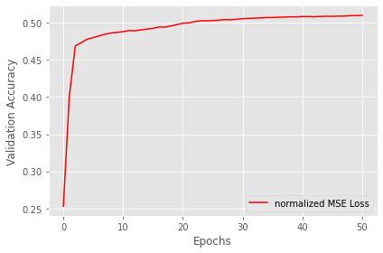

```python
print_result(nn_quad_normalize,X_train_normalized,y_train,X_test_normalized,y_test,title="normalized MSE Loss",color="red")
plt.show()
```

[.5 points] Now(1) normalize the continuous numeric feature data AND (2) one hot encode the categorical data. Use the example two-layer perceptron network from the class example and quantify performance using accuracy. Be sure that training converges by graphing the loss function versus the number of epochs.

```python
onehot_test=pd.get_dummies(X_test_normalized['State'])
X_test_onehot=X_test_normalized.drop(['State'],axis=1)
X_test_onehot=X_test_onehot.join(onehot_test)
```

```python
X_test_onehot
```

|  | TotalPop | Men | Women | Hispanic | White | Black | Native | Asian | Pacific | VotingAgeCitizen | ... | 42 | 43 | 44 | 45 | 46 | 47 | 48 | 49 | 50 | 51 |
| --- | --- | --- | --- | --- | --- | --- | --- | --- | --- | --- | --- | --- | --- | --- | --- | --- | --- | --- | --- | --- | --- |
| 0 | -0.057909 | -0.002012 | -0.110756 | -0.693592 | 0.611762 | -0.111139 | -0.076886 | -0.288414 | -0.129827 | 0.016793 | ... | 0 | 0 | 0 | 0 | 0 | 0 | 0 | 0 | 0 | 0 |
| 1 | -0.130806 | -0.050580 | -0.205348 | -0.559801 | 0.267266 | -0.006005 | -0.161345 | -0.311253 | -0.129827 | 0.006366 | ... | 0 | 0 | 0 | 0 | 0 | 0 | 0 | 0 | 0 | 0 |
| 2 | 0.034337 | 0.301987 | -0.227244 | -0.684961 | 0.956257 | -0.303123 | -0.161345 | -0.459707 | -0.129827 | 0.332866 | ... | 0 | 0 | 0 | 0 | 1 | 0 | 0 | 0 | 0 | 0 |
| 3 | 2.708132 | 4.731559 | 0.663495 | 0.130736 | -1.068468 | 1.401878 | -0.034657 | -0.322673 | -0.129827 | 3.988882 | ... | 0 | 1 | 0 | 0 | 0 | 0 | 0 | 0 | 0 | 0 |
| 4 | 0.692661 | 0.815548 | 0.554014 | 0.514846 | 0.117768 | -0.517962 | -0.055772 | -0.379770 | -0.129827 | 0.862043 | ... | 0 | 0 | 0 | 0 | 0 | 0 | 0 | 0 | 0 | 0 |
| ... | ... | ... | ... | ... | ... | ... | ... | ... | ... | ... | ... | ... | ... | ... | ... | ... | ... | ... | ... | ... | ... |
| 14539 | 0.616164 | 0.363147 | 0.845672 | 2.323188 | -1.234216 | -0.559102 | -0.161345 | -0.185639 | 0.368117 | -0.232807 | ... | 0 | 0 | 0 | 0 | 0 | 0 | 0 | 0 | 0 | 0 |
| 14540 | -1.309310 | -1.183830 | -1.395629 | -0.279270 | 0.348515 | -0.129423 | -0.098001 | -0.174219 | -0.129827 | -1.145182 | ... | 0 | 0 | 0 | 0 | 0 | 0 | 0 | 0 | 0 | 0 |
| 14541 | -1.202214 | -1.187428 | -1.183673 | -0.680645 | 1.079756 | -0.600241 | -0.013542 | -0.528224 | -0.129827 | -1.108687 | ... | 0 | 0 | 0 | 0 | 0 | 0 | 0 | 0 | 0 | 0 |
| 14542 | -0.187954 | -0.154911 | -0.214983 | 2.202345 | -1.471463 | 0.057990 | -0.161345 | -0.528224 | -0.129827 | -1.124979 | ... | 0 | 0 | 0 | 0 | 0 | 0 | 0 | 0 | 0 | 0 |
| 14543 | -0.630287 | -0.636093 | -0.607364 | -0.577064 | 0.637761 | -0.344262 | -0.161345 | 0.156946 | -0.129827 | -0.479148 | ... | 0 | 0 | 0 | 0 | 0 | 0 | 0 | 0 | 0 | 0 |

14544 rows × 85 columns

```python
onehot_train=pd.get_dummies(X_train_normalized['State'])
X_train_onehot=X_train_normalized.drop(['State'],axis=1)
X_train_onehot=X_train_onehot.join(onehot_train)
```

```python
X_train_onehot
```

|  | TotalPop | Men | Women | Hispanic | White | Black | Native | Asian | Pacific | VotingAgeCitizen | ... | 42 | 43 | 44 | 45 | 46 | 47 | 48 | 49 | 50 | 51 |
| --- | --- | --- | --- | --- | --- | --- | --- | --- | --- | --- | --- | --- | --- | --- | --- | --- | --- | --- | --- | --- | --- |
| 0 | -0.466038 | -0.397821 | -0.518207 | -0.564150 | 1.003431 | -0.606093 | -0.071673 | -0.274371 | -0.149174 | -0.413138 | ... | 0 | 0 | 0 | 0 | 0 | 0 | 0 | 0 | 0 | 0 |
| 1 | -0.933023 | -1.053268 | -0.785997 | -0.737588 | 1.036118 | -0.615392 | -0.161634 | 0.200555 | -0.149174 | -0.662623 | ... | 0 | 0 | 0 | 0 | 0 | 0 | 0 | 0 | 0 | 0 |
| 2 | -0.896819 | -0.912880 | -0.852944 | -0.061180 | 0.114330 | -0.252718 | -0.161634 | 0.145331 | -0.149174 | -0.894856 | ... | 0 | 0 | 0 | 0 | 0 | 0 | 0 | 0 | 0 | 0 |
| 3 | 3.172228 | 3.110962 | 3.132654 | 0.446126 | -0.153708 | -0.178323 | -0.161634 | -0.108699 | -0.149174 | 3.516904 | ... | 0 | 0 | 0 | 0 | 0 | 0 | 0 | 0 | 0 | 0 |
| 4 | 0.934000 | 0.754453 | 1.080495 | -0.303993 | -0.009883 | 0.212249 | -0.161634 | 0.311003 | -0.149174 | 0.951727 | ... | 0 | 0 | 0 | 0 | 0 | 0 | 0 | 0 | 0 | 0 |
| ... | ... | ... | ... | ... | ... | ... | ... | ... | ... | ... | ... | ... | ... | ... | ... | ... | ... | ... | ... | ... | ... |
| 58169 | 1.349658 | 1.257661 | 1.397379 | 0.129602 | -1.415447 | 0.328491 | 0.040778 | 3.458768 | 0.162702 | 0.868786 | ... | 0 | 0 | 0 | 0 | 0 | 0 | 0 | 0 | 0 | 0 |
| 58170 | -1.063174 | -1.104318 | -0.989517 | -0.139227 | 0.356218 | -0.280616 | -0.161634 | 0.045928 | -0.149174 | -1.053437 | ... | 0 | 0 | 0 | 0 | 0 | 0 | 0 | 0 | 0 | 0 |
| 58171 | -0.270812 | -0.184504 | -0.346822 | 1.330660 | -1.905760 | -0.517749 | 0.355642 | 4.342352 | -0.045215 | -0.661959 | ... | 0 | 0 | 0 | 0 | 0 | 0 | 0 | 0 | 0 | 0 |
| 58172 | 0.353363 | 0.375224 | 0.320866 | 1.157222 | -1.402372 | -0.615392 | 7.372614 | -0.451088 | 0.474578 | 0.042701 | ... | 0 | 0 | 0 | 0 | 0 | 0 | 0 | 0 | 0 | 0 |
| 58173 | -0.628726 | -0.817161 | -0.424481 | -0.191258 | -0.091602 | 0.430784 | -0.139144 | -0.252281 | -0.149174 | -0.247258 | ... | 0 | 0 | 0 | 0 | 0 | 0 | 0 | 0 | 0 | 0 |

58174 rows × 85 columns

```python
vals = { 'n_hidden':30,
         'C':0.1, 'epochs':50, 'eta':0.001,
         'alpha':0.001, 'decrease_const':1e-5, 'minibatches':100,
         'shuffle':True,'random_state':1}

nn_quad_normalizeonehot = TLPMiniBatch(**vals)

%time nn_quad_normalizeonehot.fit(X_train_onehot, y_train, print_progress=1, XY_test=(X_test_onehot, y_test))
print("Done")
```

```
Epoch: 50/50
```

```
Wall time: 18.3 s
Done
```

```
=================
normalized+onehot MSE Loss :
Resubstitution acc: 0.7249458520988757
Validation acc: 0.7259350935093509
```

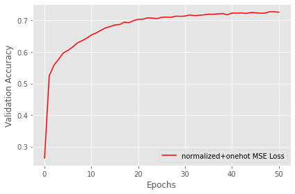

```python
print_result(nn_quad_normalizeonehot,X_train_onehot,y_train,X_test_onehot,y_test,title="normalized+onehot MSE Loss",color="red")
plt.show()
```

## [1 points] Compare the performance of the three models you just trained. Are there any meaningful differences in performance? Explain, in your own words, why these models have (or do not have) different performances.

One hot encoding creates a binary vector for each category, where the vector is the same length as the number of categories, and only one element of the vector is a 1, indicating the category.In classification tasks, the output of the MLP is a vector of probabilities representing the likelihood of each class. The one-hot encoding ensures that each class is represented by a unique vector, where all elements are zero except for the element corresponding to the class label, which is one.

One-hot encoding allows the MLP to learn the relationships between the input features and the class labels more efficiently. Since each class is represented by a unique vector, the MLP can easily distinguish between different classes and update the weights of the network accordingly during training.

Without one-hot encoding, the MLP would have difficulty distinguishing between different classes and would require additional processing to convert the categorical data into a format that can be processed by the network. This would increase the complexity of the training process and make it more difficult to achieve accurate results.

On the other hand, Normalizing the input data can help the model converge faster by reducing the number of iterations required for convergence. This is because normalization helps to reduce the variance and covariance between the features, making the optimization process easier. Normalization also can help to improve the interpretability of the model by making the weights easier to understand. When features are on different scales, it can be difficult to interpret the weights and understand the contribution of each feature to the prediction. Normalization can help to make the weights more interpretable and easier to understand.

```
=================
Resubstitution acc: 0.7249458520988757
Validation acc: 0.7259350935093509
=================
Resubstitution acc: 0.5037817581737546
Validation acc: 0.5100385038503851
=================
Resubstitution acc: 0.25129783064599304
Validation acc: 0.2473872387238724
```

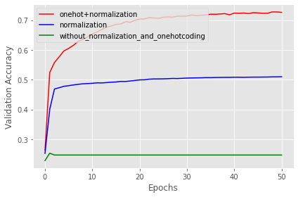

```python
print("=================")

yhat = nn_quad_normalizeonehot.predict(X_train_onehot)
print('Resubstitution acc:',accuracy_score(y_train,yhat))

yhat = nn_quad_normalizeonehot.predict(X_test_onehot)
print('Validation acc:',accuracy_score(y_test,yhat))

if hasattr(nn_quad_normalizeonehot,'val_score_'):
    plt.plot(range(len(nn_quad_normalizeonehot.val_score_)), nn_quad_normalizeonehot.val_score_, color='red',label='onehot+normalization')
    plt.ylabel('Validation Accuracy')
else:
    plt.plot(range(len(nn_quad_normalizeonehot.score_)), nn_quad_normalizeonehot.score_, color='red',label='onehot+normalization')
    plt.ylabel('Resub Accuracy')

print("=================")

yhat = nn_quad_normalize.predict(X_train_normalized)
print('Resubstitution acc:',accuracy_score(y_train,yhat))

yhat = nn_quad_normalize.predict(X_test_normalized)
print('Validation acc:',accuracy_score(y_test,yhat))

if hasattr(nn_quad_normalize,'val_score_'):
    plt.plot(range(len(nn_quad_normalize.val_score_)), nn_quad_normalize.val_score_, color='blue',label='normalization')
    plt.ylabel('Validation Accuracy')
else:
    plt.plot(range(len(nn_quad_normalize.score_)), nn_quad_normalize.score_, color='blue',label='normalization')
    plt.ylabel('Resub Accuracy')

print("=================")

yhat = nn_quad.predict(X_train)
print('Resubstitution acc:',accuracy_score(y_train,yhat))

yhat = nn_quad.predict(X_test)
print('Validation acc:',accuracy_score(y_test,yhat))

if hasattr(nn_quad,'val_score_'):
    plt.plot(range(len(nn_quad.val_score_)), nn_quad.val_score_, color='green',label='without_normalization_and_onehotcoding')
    plt.ylabel('Validation Accuracy')
else:
    plt.plot(range(len(nn_quad.score_)), nn_quad.score_, color='green',label='without_normalization_and_onehotcoding')
    plt.ylabel('Resub Accuracy')

plt.xlabel('Epochs')
plt.tight_layout()
plt.legend(loc='best')
plt.grid(True)
```

As you can see onehot+normalization have better accuracy rate and also with regularization term C=0.1 get the best performance

## Modeling (5 points total)

[1 points] Add support for a third layer in the multi-layer perceptron. Add support for saving (and plotting after training is completed) the average magnitude of the gradient for each layer, for each epoch (like we did in the flipped module for back propagation). For magnitude calculation, you are free to use either the average absolute values or the L1/L2 norm. Quantify the performance of the model and graph the magnitudes for each layer versus the number of epochs.

```python
# start with a simple base classifier, which can't be fit or predicted
# it only has internal classes to be used by classes that will subclass it
class ThreeLayerPerceptronBase(object):
    def __init__(self, n_hidden=30,n_hidden2=20,
                 C=0.0, epochs=500, eta=0.001, random_state=None):
        np.random.seed(random_state)
        self.n_hidden = n_hidden
        self.n_hidden2 = n_hidden2
        self.l2_C = C
        self.epochs = epochs
        self.eta = eta

    @staticmethod
    def _encode_labels(y):
        """Encode labels into one-hot representation"""
        onehot = pd.get_dummies(y).values.T

        return onehot

    def _initialize_weights(self):
        """Initialize weights with small random numbers."""
        W1_num_elems = (self.n_features_ + 1)*self.n_hidden
        W1 = np.random.uniform(-1.0, 1.0, size=W1_num_elems)
        W1 = W1.reshape(self.n_hidden, self.n_features_ + 1) # reshape to be W

        W2_num_elems = (self.n_hidden + 1)*self.n_hidden2
        W2 = np.random.uniform(-1.0, 1.0, size=W2_num_elems)
        W2 = W2.reshape(self.n_hidden2, self.n_hidden + 1)

        W3_num_elems = (self.n_hidden2 + 1)*self.n_output_
        W3 = np.random.uniform(-1.0, 1.0, size=W3_num_elems)
        W3 = W3.reshape(self.n_output_, self.n_hidden2 + 1)
        return W1, W2,W3

    @staticmethod
    def _sigmoid(z):
        """Use scipy.special.expit to avoid overflow"""
        # 1.0 / (1.0 + np.exp(-z))
        return expit(z)

    @staticmethod
    def _add_bias_unit(X, how='column'):
        """Add bias unit (column or row of 1s) to array at index 0"""
        if how == 'column':
            ones = np.ones((X.shape[0], 1))
            X_new = np.hstack((ones, X))
        elif how == 'row':
            ones = np.ones((1, X.shape[1]))
            X_new = np.vstack((ones, X))
        return X_new

    @staticmethod
    def _L2_reg(lambda_, W1, W2,W3):
        """Compute L2-regularization cost"""
        # only compute for non-bias terms
        return (lambda_/2.0) * np.sqrt(np.mean(W1[:, 1:] ** 2) + np.mean(W2[:, 1:] ** 2)+np.mean(W3[:, 1:] ** 2))

    def _cost(self,A4,Y_enc,W1,W2,W3):
        '''Get the objective function value'''
        cost = np.mean((Y_enc-A4)**2)
        L2_term = self._L2_reg(self.l2_C, W1, W2,W3)
        return cost + L2_term

    def _feedforward(self, X, W1, W2,W3):
        """Compute feedforward step
        """
        A1 = self._add_bias_unit(X.T, how='row')
        Z1 = W1 @ A1
        A2 = self._sigmoid(Z1)
        A2 = self._add_bias_unit(A2, how='row')
        Z2 = W2 @ A2
        A3 = self._sigmoid(Z2)
        A3 = self._add_bias_unit(A3, how='row')
        Z3 = W3 @ A3
        A4 = self._sigmoid(Z3)
        return A1, Z1, A2, Z2, A3,Z3,A4

    def _get_gradient(self, A1, A2, A3,A4, Z1, Z2,Z3, Y_enc, W1, W2,W3):
        """ Compute gradient step using backpropagation.
        """
        # vectorized backpropagation
        V3 = -2*(Y_enc-A4)*A4*(1-A4)  # last layer sensitivity
        V2 = A3*(1-A3)*(W3.T @ V3) # back prop the sensitivity
        V1 = A2*(1-A2)*(W2.T @ V2[1:,:]) # back prop the sensitivity

        grad3 = V3 @ A3.T # no bias on final layer
        grad2 = V2[1:,:] @ A2.T # dont back prop sensitivity of bias
        grad1 = V1[1:,:] @ A1.T # dont back prop sensitivity of bias


        # regularize weights that are not bias terms
        grad1[:, 1:] += W1[:, 1:] * self.l2_C
        grad2[:, 1:] += W2[:, 1:] * self.l2_C
        grad3[:, 1:] += W3[:, 1:] * self.l2_C
        return grad1, grad2,grad3

    def predict(self, X):
        """Predict class labels"""
        _, _, _, _, _,_,A4 = self._feedforward(X, self.W1, self.W2,self.W3)
        y_pred = np.argmax(A4, axis=0)
        return y_pred
```

```python
class TLPMiniBatchthree(ThreeLayerPerceptronBase):
    def __init__(self, alpha=0.0, decrease_const=0.0, shuffle=True,
                 minibatches=1, **kwds):
        # need to add to the original initializer
        self.alpha = alpha
        self.decrease_const = decrease_const
        self.shuffle = shuffle
        self.minibatches = minibatches
        # but keep other keywords
        super().__init__(**kwds)


    def fit(self, X, y, print_progress=False, XY_test=None):
        """ Learn weights from training data. With mini-batch"""
        X_data, y_data = X.copy(), y.copy()
        Y_enc = self._encode_labels(y)

        # init weights and setup matrices
        self.n_features_ = X_data.shape[1]
        self.n_output_ = Y_enc.shape[0]
        self.W1, self.W2,self.W3 = self._initialize_weights()

        rho_W1_prev = np.zeros(self.W1.shape)
        rho_W2_prev = np.zeros(self.W2.shape)
        rho_W3_prev = np.zeros(self.W3.shape)

        self.cost_ = []
        self.score_ = []
        self.gradW1_=[]
        self.gradW2_=[]
        self.gradW3_=[]

        # get starting acc
        self.score_.append(accuracy_score(y_data,self.predict(X_data)))
        # keep track of validation, if given
        if XY_test is not None:
            X_test = XY_test[0].copy()
            y_test = XY_test[1].copy()
            self.val_score_ = []
            self.val_score_.append(accuracy_score(y_test,self.predict(X_test)))

        for i in range(self.epochs):

            # adaptive learning rate
            # \frac{\eta}{1+\epsilon\cdot k}
            eta = self.eta / (1 + self.decrease_const*i)

            if print_progress>0 and (i+1)%print_progress==0:
                sys.stderr.write('\rEpoch: %d/%d' % (i+1, self.epochs))
                sys.stderr.flush()

            if self.shuffle:
                idx_shuffle = np.random.permutation(y_data.shape[0])
                X_data, Y_enc, y_data = X_data.iloc[idx_shuffle], Y_enc[:, idx_shuffle], y_data[idx_shuffle]

            mini = np.array_split(range(y_data.shape[0]), self.minibatches)
            mini_cost = []
            avg_w1=[]
            avg_w2=[]
            avg_w3=[]
            for idx in mini:

                # feedforward
                A1, Z1, A2, Z2, A3,Z3,A4 = self._feedforward(X_data.iloc[idx],
                                                       self.W1,
                                                       self.W2,self.W3)

                cost = self._cost(A4,Y_enc[:, idx],self.W1,self.W2,self.W3)
                mini_cost.append(cost) # this appends cost of mini-batch only

                # compute gradient via backpropagation
                grad1, grad2,grad3 = self._get_gradient(A1=A1, A2=A2, A3=A3,A4=A4, Z1=Z1, Z2=Z2, Z3=Z3,
                                                  Y_enc=Y_enc[:, idx],
                                                  W1=self.W1,W2=self.W2,W3=self.W3)
                avg_w1.append(np.mean(np.abs(grad1)))
                avg_w2.append(np.mean(np.abs(grad2)))
                avg_w3.append(np.mean(np.abs(grad3)))
                # momentum calculations
                rho_W1, rho_W2, rho_W3 = eta * grad1, eta * grad2, eta*grad3
                self.W1 -= (rho_W1 + (self.alpha * rho_W1_prev))
                self.W2 -= (rho_W2 + (self.alpha * rho_W2_prev))
                self.W3 -= (rho_W3 + (self.alpha * rho_W3_prev))
                rho_W1_prev, rho_W2_prev, rho_W3_prev = rho_W1, rho_W2,rho_W3
            self.gradW1_.append(avg_w1)
            self.gradW2_.append(avg_w2)
            self.gradW3_.append(avg_w3)
            self.cost_.append(mini_cost)
            self.score_.append(accuracy_score(y_data,self.predict(X_data)))
            if XY_test is not None:
                self.val_score_.append(accuracy_score(y_test,self.predict(X_test)))

        return self
```

```python
vals = { 'n_hidden':5, 'n_hidden2':5,
         'C':0.1, 'epochs':50, 'eta':0.001,
         'alpha':0.0001, 'decrease_const':10, 'minibatches':50,
         'shuffle':True,'random_state':1}

nn_quad_onehotthree = TLPMiniBatchthree(**vals)

%time nn_quad_onehotthree.fit(X_train_onehot, y_train, print_progress=1, XY_test=(X_test_onehot, y_test))
print("Done")
```

```
Epoch: 50/50
```

```
Wall time: 15.6 s
Done
```

```
=================
three layers :
Resubstitution acc: 0.45176539347474814
Validation acc: 0.4542079207920792
```

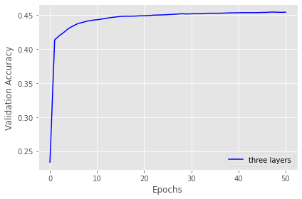

```python
print_result(nn_quad_onehotthree,X_train_onehot,y_train,X_test_onehot,y_test,title="three layers",color="blue")

plt.show()
```

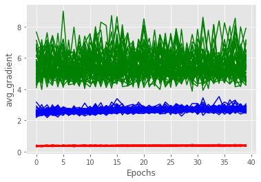

```python
plt.plot(range(len(nn_quad_onehotthree.gradW1_[10:])), nn_quad_onehotthree.gradW1_[10:], color='red')
plt.plot(range(len(nn_quad_onehotthree.gradW2_[10:])), nn_quad_onehotthree.gradW2_[10:], color='blue')
plt.plot(range(len(nn_quad_onehotthree.gradW3_[10:])), nn_quad_onehotthree.gradW3_[10:], color='green')
plt.ylabel('avg_gradient')


plt.xlabel('Epochs')
# plt.tight_layout()
# plt.legend(loc='best')
plt.grid(True)
```

[1 points] Repeat the previous step, adding support for a fourth layer.

```python
# start with a simple base classifier, which can't be fit or predicted
# it only has internal classes to be used by classes that will subclass it
class FourLayerPerceptronBase(object):
    def __init__(self, n_hidden=30,n_hidden2=20,n_hidden3=10,
                 C=0.0, epochs=500, eta=0.001, random_state=None):
        np.random.seed(random_state)
        self.n_hidden = n_hidden
        self.n_hidden2 = n_hidden2
        self.n_hidden3 = n_hidden3
        self.l2_C = C
        self.epochs = epochs
        self.eta = eta

    @staticmethod
    def _encode_labels(y):
        """Encode labels into one-hot representation"""
        onehot = pd.get_dummies(y).values.T

        return onehot

    def _initialize_weights(self):
        """Initialize weights with small random numbers."""
        W1_num_elems = (self.n_features_ + 1)*self.n_hidden
        W1 = np.random.uniform(-1.0, 1.0, size=W1_num_elems)
        W1 = W1.reshape(self.n_hidden, self.n_features_ + 1) # reshape to be W

        W2_num_elems = (self.n_hidden + 1)*self.n_hidden2
        W2 = np.random.uniform(-1.0, 1.0, size=W2_num_elems)
        W2 = W2.reshape(self.n_hidden2, self.n_hidden + 1)

        W3_num_elems = (self.n_hidden2 + 1)*self.n_hidden3
        W3 = np.random.uniform(-1.0, 1.0, size=W3_num_elems)
        W3 = W3.reshape(self.n_hidden3, self.n_hidden2 + 1)

        W4_num_elems = (self.n_hidden3 + 1)*self.n_output_
        W4 = np.random.uniform(-1.0, 1.0, size=W4_num_elems)
        W4 = W4.reshape(self.n_output_, self.n_hidden3 + 1)
        return W1, W2,W3,W4

    @staticmethod
    def _sigmoid(z):
        """Use scipy.special.expit to avoid overflow"""
        # 1.0 / (1.0 + np.exp(-z))
        return expit(z)

    @staticmethod
    def _add_bias_unit(X, how='column'):
        """Add bias unit (column or row of 1s) to array at index 0"""
        if how == 'column':
            ones = np.ones((X.shape[0], 1))
            X_new = np.hstack((ones, X))
        elif how == 'row':
            ones = np.ones((1, X.shape[1]))
            X_new = np.vstack((ones, X))
        return X_new

    @staticmethod
    def _L2_reg(lambda_, W1, W2,W3,W4):
        """Compute L2-regularization cost"""
        # only compute for non-bias terms
        return (lambda_/2.0) * np.sqrt(np.mean(W1[:, 1:] ** 2) + np.mean(W2[:, 1:] ** 2)+np.mean(W3[:, 1:] ** 2)+np.mean(W4[:, 1:] ** 2))

    def _cost(self,A5,Y_enc,W1,W2,W3,W4):
        '''Get the objective function value'''
        cost = np.mean((Y_enc-A5)**2)
        L2_term = self._L2_reg(self.l2_C, W1, W2,W3,W4)
        return cost + L2_term

    def _feedforward(self, X, W1, W2,W3,W4):
        """Compute feedforward step
        """
        A1 = self._add_bias_unit(X.T, how='row')
        Z1 = W1 @ A1
        A2 = self._sigmoid(Z1)
        A2 = self._add_bias_unit(A2, how='row')
        Z2 = W2 @ A2
        A3 = self._sigmoid(Z2)
        A3 = self._add_bias_unit(A3, how='row')
        Z3 = W3 @ A3
        A4 = self._sigmoid(Z3)
        A4 = self._add_bias_unit(A4, how='row')
        Z4 = W4 @ A4
        A5 = self._sigmoid(Z4)
        return A1, Z1, A2, Z2, A3,Z3,A4,Z4,A5

    def _get_gradient(self, A1, A2, A3,A4,A5, Z1, Z2,Z3,Z4, Y_enc, W1, W2,W3,W4):
        """ Compute gradient step using backpropagation.
        """
        # vectorized backpropagation
        V4 = -2*(Y_enc-A5)*A5*(1-A5)  # last layer sensitivity
        V3 = A4*(1-A4)*(W4.T @ V4) # back prop the sensitivity
        V2 = A3*(1-A3)*(W3.T @ V3[1:,:]) # back prop the sensitivity
        V1 = A2*(1-A2)*(W2.T @ V2[1:,:]) # back prop the sensitivity

        grad4 = V4 @ A4.T # no bias on final layer
        grad3 = V3[1:,:] @ A3.T # dont back prop sensitivity of bias
        grad2 = V2[1:,:] @ A2.T # dont back prop sensitivity of bias
        grad1 = V1[1:,:] @ A1.T # dont back prop sensitivity of bias


        # regularize weights that are not bias terms
        grad1[:, 1:] += W1[:, 1:] * self.l2_C
        grad2[:, 1:] += W2[:, 1:] * self.l2_C
        grad3[:, 1:] += W3[:, 1:] * self.l2_C
        grad4[:, 1:] += W4[:, 1:] * self.l2_C
        return grad1, grad2,grad3,grad4

    def predict(self, X):
        """Predict class labels"""
        _, _, _, _, _,_,_,_,A5 = self._feedforward(X, self.W1, self.W2,self.W3,self.W4)
        y_pred = np.argmax(A5, axis=0)
        return y_pred
```

```python
class TLPMiniBatchFour(FourLayerPerceptronBase):
    def __init__(self, alpha=0.0, decrease_const=0.0, shuffle=True,
                 minibatches=1, **kwds):
        # need to add to the original initializer
        self.alpha = alpha
        self.decrease_const = decrease_const
        self.shuffle = shuffle
        self.minibatches = minibatches
        # but keep other keywords
        super().__init__(**kwds)


    def fit(self, X, y, print_progress=False, XY_test=None):
        """ Learn weights from training data. With mini-batch"""
        X_data, y_data = X.copy(), y.copy()
        Y_enc = self._encode_labels(y)

        # init weights and setup matrices
        self.n_features_ = X_data.shape[1]
        self.n_output_ = Y_enc.shape[0]
        self.W1, self.W2,self.W3,self.W4 = self._initialize_weights()

        rho_W1_prev = np.zeros(self.W1.shape)
        rho_W2_prev = np.zeros(self.W2.shape)
        rho_W3_prev = np.zeros(self.W3.shape)
        rho_W4_prev = np.zeros(self.W4.shape)

        self.cost_ = []
        self.score_ = []
        self.gradW1_=[]
        self.gradW2_=[]
        self.gradW3_=[]
        self.gradW4_=[]

        # get starting acc
        self.score_.append(accuracy_score(y_data,self.predict(X_data)))
        # keep track of validation, if given
        if XY_test is not None:
            X_test = XY_test[0].copy()
            y_test = XY_test[1].copy()
            self.val_score_ = []
            self.val_score_.append(accuracy_score(y_test,self.predict(X_test)))

        for i in range(self.epochs):

            # adaptive learning rate
            # \frac{\eta}{1+\epsilon\cdot k}
            eta = self.eta / (1 + self.decrease_const*i)

            if print_progress>0 and (i+1)%print_progress==0:
                sys.stderr.write('\rEpoch: %d/%d' % (i+1, self.epochs))
                sys.stderr.flush()

            if self.shuffle:
                idx_shuffle = np.random.permutation(y_data.shape[0])
                X_data, Y_enc, y_data = X_data.iloc[idx_shuffle], Y_enc[:, idx_shuffle], y_data[idx_shuffle]

            mini = np.array_split(range(y_data.shape[0]), self.minibatches)
            mini_cost = []
            avg_w1=[]
            avg_w2=[]
            avg_w3=[]
            avg_w4=[]
            for idx in mini:

                # feedforward
                A1, Z1, A2, Z2, A3,Z3,A4,Z4,A5 = self._feedforward(X_data.iloc[idx],
                                                       self.W1,
                                                       self.W2,self.W3,self.W4)

                cost = self._cost(A5,Y_enc[:, idx],self.W1,self.W2,self.W3,self.W4)
                mini_cost.append(cost) # this appends cost of mini-batch only

                # compute gradient via backpropagation
                grad1, grad2,grad3,grad4 = self._get_gradient(A1=A1, A2=A2, A3=A3,A4=A4,A5=A5, Z1=Z1, Z2=Z2, Z3=Z3,Z4=Z4,
                                                  Y_enc=Y_enc[:, idx],
                                                  W1=self.W1,W2=self.W2,W3=self.W3,W4=self.W4)
                avg_w1.append(np.mean(np.abs(grad1)))
                avg_w2.append(np.mean(np.abs(grad2)))
                avg_w3.append(np.mean(np.abs(grad3)))
                avg_w4.append(np.mean(np.abs(grad4)))
                # momentum calculations
                rho_W1, rho_W2, rho_W3,rho_W4 = eta * grad1, eta * grad2, eta*grad3,eta*grad4
                self.W1 -= (rho_W1 + (self.alpha * rho_W1_prev))
                self.W2 -= (rho_W2 + (self.alpha * rho_W2_prev))
                self.W3 -= (rho_W3 + (self.alpha * rho_W3_prev))
                self.W4 -= (rho_W4 + (self.alpha * rho_W4_prev))
                rho_W1_prev, rho_W2_prev, rho_W3_prev , rho_W4_prev= rho_W1, rho_W2,rho_W3,rho_W4
            self.gradW1_.append(avg_w1)
            self.gradW2_.append(avg_w2)
            self.gradW3_.append(avg_w3)
            self.gradW4_.append(avg_w4)
            self.cost_.append(mini_cost)
            self.score_.append(accuracy_score(y_data,self.predict(X_data)))
            if XY_test is not None:
                self.val_score_.append(accuracy_score(y_test,self.predict(X_test)))

        return self
```

```python
vals = { 'n_hidden':50, 'n_hidden2':20,'n_hidden3':10,
         'C':0.1, 'epochs':50, 'eta':0.001,
         'alpha':0.001, 'decrease_const':10, 'minibatches':50,
         'shuffle':True,'random_state':1}

nn_quad_onehotFour = TLPMiniBatchFour(**vals)

%time nn_quad_onehotFour.fit(X_train_onehot, y_train, print_progress=1, XY_test=(X_test_onehot, y_test))
print("Done")
```

```
Epoch: 50/50
```

```
Wall time: 30.8 s
Done
```

```
=================
Four layers :
Resubstitution acc: 0.4644858527864682
Validation acc: 0.46624037403740376
```

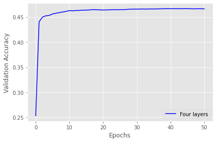

```python
print_result(nn_quad_onehotFour,X_train_onehot,y_train,X_test_onehot,y_test,title="Four layers",color="blue")

plt.show()
```

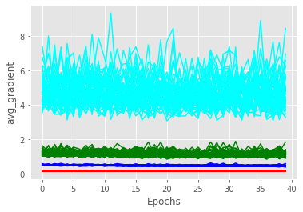

```python
plt.plot(range(len(nn_quad_onehotFour.gradW1_[10:])), nn_quad_onehotFour.gradW1_[10:], color='red')
plt.plot(range(len(nn_quad_onehotFour.gradW2_[10:])), nn_quad_onehotFour.gradW2_[10:], color='blue')
plt.plot(range(len(nn_quad_onehotFour.gradW3_[10:])), nn_quad_onehotFour.gradW3_[10:], color='green')
plt.plot(range(len(nn_quad_onehotFour.gradW4_[10:])), nn_quad_onehotFour.gradW4_[10:], color='cyan')
plt.ylabel('avg_gradient')


plt.xlabel('Epochs')
# plt.tight_layout()
# plt.legend(loc='best')
plt.grid(True)
```

[1 points] Repeat the previous step, adding support for a fifth layer.

```python
# start with a simple base classifier, which can't be fit or predicted
# it only has internal classes to be used by classes that will subclass it
class FiveLayerPerceptronBase(object):
    def __init__(self, n_hidden=30,n_hidden2=20,n_hidden3=10,n_hidden4=5,
                 C=0.0, epochs=500, eta=0.001, random_state=None):
        np.random.seed(random_state)
        self.n_hidden = n_hidden
        self.n_hidden2 = n_hidden2
        self.n_hidden3 = n_hidden3
        self.n_hidden4 = n_hidden4
        self.l2_C = C
        self.epochs = epochs
        self.eta = eta

    @staticmethod
    def _encode_labels(y):
        """Encode labels into one-hot representation"""
        onehot = pd.get_dummies(y).values.T

        return onehot

    def _initialize_weights(self):
        """Initialize weights with small random numbers."""
        W1_num_elems = (self.n_features_ + 1)*self.n_hidden
        W1 = np.random.uniform(-1.0, 1.0, size=W1_num_elems)
        W1 = W1.reshape(self.n_hidden, self.n_features_ + 1) # reshape to be W

        W2_num_elems = (self.n_hidden + 1)*self.n_hidden2
        W2 = np.random.uniform(-1.0, 1.0, size=W2_num_elems)
        W2 = W2.reshape(self.n_hidden2, self.n_hidden + 1)

        W3_num_elems = (self.n_hidden2 + 1)*self.n_hidden3
        W3 = np.random.uniform(-1.0, 1.0, size=W3_num_elems)
        W3 = W3.reshape(self.n_hidden3, self.n_hidden2 + 1)

        W4_num_elems = (self.n_hidden3 + 1)*self.n_hidden4
        W4 = np.random.uniform(-1.0, 1.0, size=W4_num_elems)
        W4 = W4.reshape(self.n_hidden4, self.n_hidden3 + 1)

        W5_num_elems = (self.n_hidden4 + 1)*self.n_output_
        W5 = np.random.uniform(-1.0, 1.0, size=W5_num_elems)
        W5 = W5.reshape(self.n_output_, self.n_hidden4 + 1)
        return W1, W2,W3,W4,W5

    @staticmethod
    def _sigmoid(z):
        """Use scipy.special.expit to avoid overflow"""
        # 1.0 / (1.0 + np.exp(-z))
        return expit(z)

    @staticmethod
    def _add_bias_unit(X, how='column'):
        """Add bias unit (column or row of 1s) to array at index 0"""
        if how == 'column':
            ones = np.ones((X.shape[0], 1))
            X_new = np.hstack((ones, X))
        elif how == 'row':
            ones = np.ones((1, X.shape[1]))
            X_new = np.vstack((ones, X))
        return X_new

    @staticmethod
    def _L2_reg(lambda_, W1, W2,W3,W4,W5):
        """Compute L2-regularization cost"""
        # only compute for non-bias terms
        return (lambda_/2.0) * np.sqrt(np.mean(W1[:, 1:] ** 2
                                              ) + np.mean(W2[:, 1:] ** 2
                                                         )+np.mean(W3[:, 1:] ** 2)+np.mean(W4[:, 1:] ** 2)+np.mean(W5[:, 1:] ** 2))

    def _cost(self,A6,Y_enc,W1,W2,W3,W4,W5):
        '''Get the objective function value'''
        cost = np.mean((Y_enc-A6)**2)
        L2_term = self._L2_reg(self.l2_C, W1, W2,W3,W4,W5)
        return cost + L2_term

    def _feedforward(self, X, W1, W2,W3,W4,W5):
        """Compute feedforward step
        """
        A1 = self._add_bias_unit(X.T, how='row')
        Z1 = W1 @ A1
        A2 = self._sigmoid(Z1)
        A2 = self._add_bias_unit(A2, how='row')
        Z2 = W2 @ A2
        A3 = self._sigmoid(Z2)
        A3 = self._add_bias_unit(A3, how='row')
        Z3 = W3 @ A3
        A4 = self._sigmoid(Z3)
        A4 = self._add_bias_unit(A4, how='row')
        Z4 = W4 @ A4
        A5 = self._sigmoid(Z4)
        A5 = self._add_bias_unit(A5, how='row')
        Z5 = W5 @ A5
        A6 = self._sigmoid(Z5)
        return A1, Z1, A2, Z2, A3,Z3,A4,Z4,A5,Z5,A6

    def _get_gradient(self, A1, A2, A3,A4,A5,A6, Z1, Z2,Z3,Z4,Z5, Y_enc, W1, W2,W3,W4,W5):
        """ Compute gradient step using backpropagation.
        """
        # vectorized backpropagation
        V5 = -2*(Y_enc-A6)*A6*(1-A6)  # last layer sensitivity
        V4 = A5*(1-A5)*(W5.T @ V5) # back prop the sensitivity
        V3 = A4*(1-A4)*(W4.T @ V4[1:,:]) # back prop the sensitivity
        V2 = A3*(1-A3)*(W3.T @ V3[1:,:]) # back prop the sensitivity
        V1 = A2*(1-A2)*(W2.T @ V2[1:,:]) # back prop the sensitivity

        grad5 = V5 @ A5.T # no bias on final layer
        grad4 = V4[1:,:] @ A4.T # dont back prop sensitivity of bias
        grad3 = V3[1:,:] @ A3.T # dont back prop sensitivity of bias
        grad2 = V2[1:,:] @ A2.T # dont back prop sensitivity of bias
        grad1 = V1[1:,:] @ A1.T # dont back prop sensitivity of bias


        # regularize weights that are not bias terms
        grad1[:, 1:] += W1[:, 1:] * self.l2_C
        grad2[:, 1:] += W2[:, 1:] * self.l2_C
        grad3[:, 1:] += W3[:, 1:] * self.l2_C
        grad4[:, 1:] += W4[:, 1:] * self.l2_C
        grad5[:, 1:] += W5[:, 1:] * self.l2_C
        return grad1, grad2,grad3,grad4,grad5

    def predict(self, X):
        """Predict class labels"""
        _, _, _, _, _,_,_,_,_,_,A6 = self._feedforward(X, self.W1, self.W2,self.W3,self.W4,self.W5)
        y_pred = np.argmax(A6, axis=0)
        return y_pred
```

```python
class TLPMiniBatchFive(FiveLayerPerceptronBase):
    def __init__(self, alpha=0.0, decrease_const=0.0, shuffle=True,
                 minibatches=1,eps=1e-8, **kwds):
        # need to add to the original initializer
        self.alpha = alpha
        self.decrease_const = decrease_const
        self.shuffle = shuffle
        self.minibatches = minibatches
        self.eps=eps
        # but keep other keywords
        super().__init__(**kwds)


    def fit(self, X, y, print_progress=False, XY_test=None):
        """ Learn weights from training data. With mini-batch"""
        X_data, y_data = X.copy(), y.copy()
        Y_enc = self._encode_labels(y)

        # init weights and setup matrices
        self.n_features_ = X_data.shape[1]
        self.n_output_ = Y_enc.shape[0]
        self.W1, self.W2,self.W3,self.W4,self.W5 = self._initialize_weights()

        rho_W1_prev = np.zeros(self.W1.shape)
        rho_W2_prev = np.zeros(self.W2.shape)
        rho_W3_prev = np.zeros(self.W3.shape)
        rho_W4_prev = np.zeros(self.W4.shape)
        rho_W5_prev = np.zeros(self.W5.shape)

        self.cost_ = []
        self.score_ = []
        self.gradW1_=[]
        self.gradW2_=[]
        self.gradW3_=[]
        self.gradW4_=[]
        self.gradW5_=[]

        # get starting acc
        self.score_.append(accuracy_score(y_data,self.predict(X_data)))
        # keep track of validation, if given
        if XY_test is not None:
            X_test = XY_test[0].copy()
            y_test = XY_test[1].copy()
            self.val_score_ = []
            self.val_score_.append(accuracy_score(y_test,self.predict(X_test)))

        for i in range(self.epochs):

            # adaptive learning rate
            # \frac{\eta}{1+\epsilon\cdot k}
            eta = self.eta / (1 + self.decrease_const*i)

            if print_progress>0 and (i+1)%print_progress==0:
                sys.stderr.write('\rEpoch: %d/%d' % (i+1, self.epochs))
                sys.stderr.flush()

            if self.shuffle:
                idx_shuffle = np.random.permutation(y_data.shape[0])
                X_data, Y_enc, y_data = X_data.iloc[idx_shuffle], Y_enc[:, idx_shuffle], y_data[idx_shuffle]

            mini = np.array_split(range(y_data.shape[0]), self.minibatches)
            mini_cost = []
            avg_w1=[]
            avg_w2=[]
            avg_w3=[]
            avg_w4=[]
            avg_w5=[]
            for idx in mini:

                # feedforward
                A1, Z1, A2, Z2, A3,Z3,A4,Z4,A5,Z5,A6 = self._feedforward(X_data.iloc[idx],
                                                       self.W1,
                                                       self.W2,self.W3,self.W4,self.W5)

                cost = self._cost(A6,Y_enc[:, idx],self.W1,self.W2,self.W3,self.W4,self.W5)
                mini_cost.append(cost) # this appends cost of mini-batch only

                # compute gradient via backpropagation
                grad1, grad2,grad3,grad4,grad5 = self._get_gradient(A1=A1, A2=A2, A3=A3,A4=A4,A5=A5,A6=A6, Z1=Z1, Z2=Z2, Z3=Z3,Z4=Z4,
                                                  Z5=Z5,Y_enc=Y_enc[:, idx],
                                                  W1=self.W1,W2=self.W2,W3=self.W3,W4=self.W4,W5=self.W5)
                avg_w1.append(np.mean(np.abs(grad1)))
                avg_w2.append(np.mean(np.abs(grad2)))
                avg_w3.append(np.mean(np.abs(grad3)))
                avg_w4.append(np.mean(np.abs(grad4)))
                avg_w5.append(np.mean(np.abs(grad5)))
                # momentum calculations
                rho_W1, rho_W2, rho_W3,rho_W4,rho_W5 = eta * grad1, eta * grad2, eta*grad3,eta*grad4,eta*grad5
                self.W1 -= (rho_W1 + (self.alpha * rho_W1_prev))
                self.W2 -= (rho_W2 + (self.alpha * rho_W2_prev))
                self.W3 -= (rho_W3 + (self.alpha * rho_W3_prev))
                self.W4 -= (rho_W4 + (self.alpha * rho_W4_prev))
                self.W5 -= (rho_W5 + (self.alpha * rho_W5_prev))
                rho_W1_prev, rho_W2_prev, rho_W3_prev , rho_W4_prev, rho_W5_prev= rho_W1, rho_W2,rho_W3,rho_W4,rho_W5
            self.gradW1_.append(avg_w1)
            self.gradW2_.append(avg_w2)
            self.gradW3_.append(avg_w3)
            self.gradW4_.append(avg_w4)
            self.gradW5_.append(avg_w5)
            self.cost_.append(mini_cost)
            self.score_.append(accuracy_score(y_data,self.predict(X_data)))
            if XY_test is not None:
                self.val_score_.append(accuracy_score(y_test,self.predict(X_test)))

        return self
```

```python
vals = { 'n_hidden':50, 'n_hidden2':20,
         'C':0.1, 'epochs':50, 'eta':0.01,
         'alpha':0.0001, 'decrease_const':10, 'minibatches':50,
         'shuffle':True,'random_state':1}

nn_quad_onehotFive = TLPMiniBatchFive(**vals)

%time nn_quad_onehotFive.fit(X_train_onehot, y_train, print_progress=1, XY_test=(X_test_onehot, y_test))
print("Done")
```

```
Epoch: 50/50
```

```
Wall time: 29.4 s
Done
```

```
=================
Five layers :
Resubstitution acc: 0.6088630659744904
Validation acc: 0.6068481848184818
```

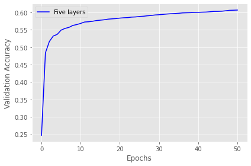

```python
print_result(nn_quad_onehotFive,X_train_onehot,y_train,X_test_onehot,y_test,title="Five layers",color="blue")

plt.show()
```

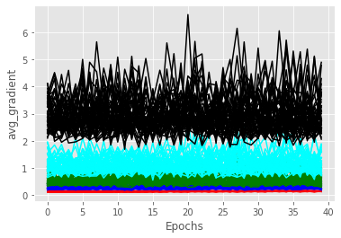

```python
plt.plot(range(len(nn_quad_onehotFive.gradW1_[10:])), nn_quad_onehotFive.gradW1_[10:], color='red')
plt.plot(range(len(nn_quad_onehotFive.gradW2_[10:])), nn_quad_onehotFive.gradW2_[10:], color='blue')
plt.plot(range(len(nn_quad_onehotFive.gradW3_[10:])), nn_quad_onehotFive.gradW3_[10:], color='green')
plt.plot(range(len(nn_quad_onehotFive.gradW4_[10:])), nn_quad_onehotFive.gradW4_[10:], color='cyan')
plt.plot(range(len(nn_quad_onehotFive.gradW5_[10:])), nn_quad_onehotFive.gradW5_[10:], color='k')
plt.ylabel('avg_gradient')


plt.xlabel('Epochs')
# plt.tight_layout()
# plt.legend(loc='best')
plt.grid(True)
```

[2 points] Implement an adaptive learning technique that was discussed in lecture and use it on the five layer network (such as AdaGrad, RMSProps, or AdaDelta). Discuss which adaptive method you chose. Compare the performance of your five layer model with and without the adaptive learning strategy. Do not use AdaM for the adaptive learning technique as it is part of the exceptional work.

```python
class TLPMiniBatchFiveAdaGrad(FiveLayerPerceptronBase):
    def __init__(self, alpha=0.0, decrease_const=0.0, shuffle=True,
                 minibatches=1,eps=1e-8, **kwds):
        # need to add to the original initializer
        self.alpha = alpha
        self.decrease_const = decrease_const
        self.shuffle = shuffle
        self.minibatches = minibatches
        self.eps=eps
        # but keep other keywords
        super().__init__(**kwds)


    def fit(self, X, y, print_progress=False, XY_test=None):
        """ Learn weights from training data. With mini-batch"""
        X_data, y_data = X.copy(), y.copy()
        Y_enc = self._encode_labels(y)

        # init weights and setup matrices
        self.n_features_ = X_data.shape[1]
        self.n_output_ = Y_enc.shape[0]
        self.W1, self.W2,self.W3,self.W4,self.W5 = self._initialize_weights()

        G_W1 = np.zeros(self.W1.shape)
        G_W2 = np.zeros(self.W2.shape)
        G_W3 = np.zeros(self.W3.shape)
        G_W4 = np.zeros(self.W4.shape)
        G_W5 = np.zeros(self.W5.shape)

        self.cost_ = []
        self.score_ = []
        self.gradW1_=[]
        self.gradW2_=[]
        self.gradW3_=[]
        self.gradW4_=[]
        self.gradW5_=[]

        # get starting acc
        self.score_.append(accuracy_score(y_data,self.predict(X_data)))
        # keep track of validation, if given
        if XY_test is not None:
            X_test = XY_test[0].copy()
            y_test = XY_test[1].copy()
            self.val_score_ = []
            self.val_score_.append(accuracy_score(y_test,self.predict(X_test)))

        for i in range(self.epochs):

            # adaptive learning rate
            # \frac{\eta}{1+\epsilon\cdot k}
            eta = self.eta / (1 + self.decrease_const*i)

            if print_progress>0 and (i+1)%print_progress==0:
                sys.stderr.write('\rEpoch: %d/%d' % (i+1, self.epochs))
                sys.stderr.flush()

            if self.shuffle:
                idx_shuffle = np.random.permutation(y_data.shape[0])
                X_data, Y_enc, y_data = X_data.iloc[idx_shuffle], Y_enc[:, idx_shuffle], y_data[idx_shuffle]

            mini = np.array_split(range(y_data.shape[0]), self.minibatches)
            mini_cost = []
            avg_w1=[]
            avg_w2=[]
            avg_w3=[]
            avg_w4=[]
            avg_w5=[]
            for idx in mini:

                # feedforward
                A1, Z1, A2, Z2, A3,Z3,A4,Z4,A5,Z5,A6 = self._feedforward(X_data.iloc[idx],
                                                       self.W1,
                                                       self.W2,self.W3,self.W4,self.W5)

                cost = self._cost(A6,Y_enc[:, idx],self.W1,self.W2,self.W3,self.W4,self.W5)
                mini_cost.append(cost) # this appends cost of mini-batch only

                # compute gradient via backpropagation
                grad1, grad2,grad3,grad4,grad5 = self._get_gradient(A1=A1, A2=A2, A3=A3,A4=A4,A5=A5,A6=A6, Z1=Z1, Z2=Z2, Z3=Z3,Z4=Z4,
                                                  Z5=Z5,Y_enc=Y_enc[:, idx],
                                                  W1=self.W1,W2=self.W2,W3=self.W3,W4=self.W4,W5=self.W5)
                avg_w1.append(np.mean(np.abs(grad1)))
                avg_w2.append(np.mean(np.abs(grad2)))
                avg_w3.append(np.mean(np.abs(grad3)))
                avg_w4.append(np.mean(np.abs(grad4)))
                avg_w5.append(np.mean(np.abs(grad5)))
                # momentum calculations
                G_W1 += grad1**2
                G_W2 += grad2**2
                G_W3 += grad3**2
                G_W4 += grad4**2
                G_W5 += grad5**2
                self.W1 -= (self.eta* grad1) / (np.sqrt(G_W1 + self.eps))
                self.W2 -= (self.eta* grad2) / (np.sqrt(G_W2 + self.eps))
                self.W3 -= (self.eta* grad3) / (np.sqrt(G_W3 + self.eps))
                self.W4 -= (self.eta* grad4) / (np.sqrt(G_W4 + self.eps))
                self.W5 -= (self.eta* grad5) / (np.sqrt(G_W5 + self.eps))


            self.gradW1_.append(avg_w1)
            self.gradW2_.append(avg_w2)
            self.gradW3_.append(avg_w3)
            self.gradW4_.append(avg_w4)
            self.gradW5_.append(avg_w5)
            self.cost_.append(mini_cost)
            self.score_.append(accuracy_score(y_data,self.predict(X_data)))
            if XY_test is not None:
                self.val_score_.append(accuracy_score(y_test,self.predict(X_test)))

        return self
```

```python
vals = { 'n_hidden':50, 'n_hidden2':20,'n_hidden3':10,
         'C':0.01, 'epochs':50, 'eta':0.1,
          'decrease_const':10, 'minibatches':100,
         'shuffle':True,'random_state':1}

nn_AdaGrad_onehotFive = TLPMiniBatchFiveAdaGrad(**vals)

%time nn_AdaGrad_onehotFive.fit(X_train_onehot, y_train, print_progress=1, XY_test=(X_test_onehot, y_test))
print("Done")
```

```
Epoch: 50/50
```

```
Wall time: 36 s
Done
```

```
=================
Five layers :
Resubstitution acc: 0.7544951352838037
Validation acc: 0.7341859185918592
```

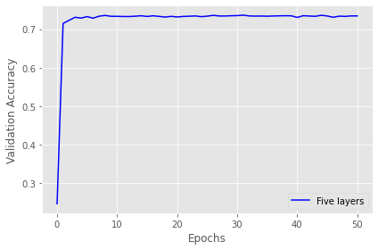

```python
print_result(nn_AdaGrad_onehotFive,X_train_onehot,y_train,X_test_onehot,y_test,title="Five layers",color="blue")

plt.show()
```

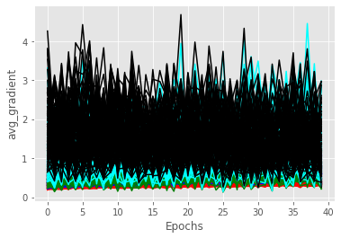

```python
plt.plot(range(len(nn_AdaGrad_onehotFive.gradW1_[10:])), nn_AdaGrad_onehotFive.gradW1_[10:], color='red')
plt.plot(range(len(nn_AdaGrad_onehotFive.gradW2_[10:])), nn_AdaGrad_onehotFive.gradW2_[10:], color='blue')
plt.plot(range(len(nn_AdaGrad_onehotFive.gradW3_[10:])), nn_AdaGrad_onehotFive.gradW3_[10:], color='green')
plt.plot(range(len(nn_AdaGrad_onehotFive.gradW4_[10:])), nn_AdaGrad_onehotFive.gradW4_[10:], color='cyan')
plt.plot(range(len(nn_AdaGrad_onehotFive.gradW5_[10:])), nn_AdaGrad_onehotFive.gradW5_[10:], color='k')
plt.ylabel('avg_gradient')


plt.xlabel('Epochs')
# plt.tight_layout()
# plt.legend(loc='best')
plt.grid(True)
```

```python
vals = { 'n_hidden':50, 'n_hidden2':20,'n_hidden3':10,
         'C':0.001, 'epochs':50, 'eta':0.001,
         'alpha':0.001, 'decrease_const':0.001, 'minibatches':100,
         'shuffle':True,'random_state':1}

nn_AdaGrad_onehotFive = TLPMiniBatchFiveAdaGrad(**vals)

%time nn_AdaGrad_onehotFive.fit(X_train_onehot, y_train, print_progress=1, XY_test=(X_test_onehot, y_test))
print("Done")
```

```
Epoch: 50/50
```

```
Wall time: 41.5 s
Done
```

```
=================
Five layers :
Resubstitution acc: 0.2513150204558738
Validation acc: 0.24711221122112212
```

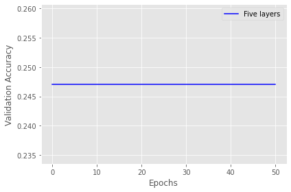

```python
print_result(nn_AdaGrad_onehotFive,X_train_onehot,y_train,X_test_onehot,y_test,title="Five layers",color="blue")

plt.show()
```

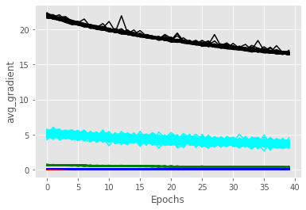

```python
plt.plot(range(len(nn_AdaGrad_onehotFive.gradW1_[10:])), nn_AdaGrad_onehotFive.gradW1_[10:], color='red')
plt.plot(range(len(nn_AdaGrad_onehotFive.gradW2_[10:])), nn_AdaGrad_onehotFive.gradW2_[10:], color='blue')
plt.plot(range(len(nn_AdaGrad_onehotFive.gradW3_[10:])), nn_AdaGrad_onehotFive.gradW3_[10:], color='green')
plt.plot(range(len(nn_AdaGrad_onehotFive.gradW4_[10:])), nn_AdaGrad_onehotFive.gradW4_[10:], color='cyan')
plt.plot(range(len(nn_AdaGrad_onehotFive.gradW5_[10:])), nn_AdaGrad_onehotFive.gradW5_[10:], color='k')
plt.ylabel('avg_gradient')


plt.xlabel('Epochs')
# plt.tight_layout()
# plt.legend(loc='best')
plt.grid(True)
```

I used AdaGrad as my adaptivelearning rate optimization algorithm. It modifies the learning rate of each parameter of the neural network based on the historical gradients of that parameter. This means that the learning rate is adjusted automatically based on how frequently and intensely a parameter is updated during training. Parameters that receive larger gradients will have a smaller learning rate, while parameters that receive smaller gradients will have a larger learning rate.

In contrast to non-adaptive optimization methods, AdaGrad automatically tunes the learning rate for each parameter based on the historical gradient information. This can be especially useful in situations where the input data has a large variation in the feature scales, or where some features have rare events that require a different learning rate.

However, AdaGrad has a disadvantage in that it accumulates the squares of the gradient magnitudes over time, leading to a decaying learning rate for parameters that have been updated frequently in the past. Also as the learning rate decreases over time in AdaGrad can lead to slower convergence or getting stuck in a suboptimal solution.Moreover, AdaGrad performs poorly with sparse data because the gradient updates can be dominated by small gradients, which can result in a suboptimal solution. As a result, AdaGrad may not be well-suited for deep neural networks or problems with high-dimensional parameter spaces, where the accumulated gradients can lead to an overly conservative learning rate.

# Exceptional Work (1 points total)

One idea (required for 7000 level students): Implement adaptive momentum (AdaM) in the five layer neural network and quantify the performance.

```python
class TLPAdaM(FiveLayerPerceptronBase):
    def __init__(self, alpha=0.9, beta1=0.9, beta2=0.999, eps=1e-8,decrease_const=1e-5,shuffle=True,minibatches=100, **kwds):
        self.alpha = alpha  # momentum coefficient
        self.beta1 = beta1  # exponential decay rate for the first moment estimate
        self.beta2 = beta2  # exponential decay rate for the second moment estimate
        self.eps=eps  # small constant to prevent division by zero in RMS term
        self.decrease_const = decrease_const
        self.shuffle = shuffle
        self.minibatches = minibatches

        # but keep other keywords
        super().__init__(**kwds)

    def fit(self, X, y, print_progress=False, XY_test=None):
        X_data, y_data = X.copy(), y.copy()
        Y_enc = self._encode_labels(y)
        self.n_features_ = X_data.shape[1]
        self.n_output_ = Y_enc.shape[0]
        self.W1, self.W2,self.W3,self.W4,self.W5 = self._initialize_weights()

        m_W1 = np.zeros(self.W1.shape)
        v_W1 = np.zeros(self.W1.shape)
        m_W2 = np.zeros(self.W2.shape)
        v_W2 = np.zeros(self.W2.shape)
        m_W3 = np.zeros(self.W3.shape)
        v_W3 = np.zeros(self.W3.shape)
        m_W4 = np.zeros(self.W4.shape)
        v_W4 = np.zeros(self.W4.shape)
        m_W5 = np.zeros(self.W5.shape)
        v_W5 = np.zeros(self.W5.shape)

        self.cost_ = []
        self.score_ = []
        self.gradW1_=[]
        self.gradW2_=[]
        self.gradW3_=[]
        self.gradW4_=[]
        self.gradW5_=[]
        self.score_.append(accuracy_score(y_data,self.predict(X_data)))

        if XY_test is not None:
            X_test = XY_test[0].copy()
            y_test = XY_test[1].copy()
            self.val_score_ = []
            self.val_score_.append(accuracy_score(y_test,self.predict(X_test)))

        for i in range(self.epochs):
            eta = self.eta / (1 + self.decrease_const*i)

            if print_progress>0 and (i+1)%print_progress==0:
                sys.stderr.write('\rEpoch: %d/%d' % (i+1, self.epochs))
                sys.stderr.flush()

            if self.shuffle:
                idx_shuffle = np.random.permutation(y_data.shape[0])
                X_data, Y_enc, y_data = X_data.iloc[idx_shuffle], Y_enc[:, idx_shuffle], y_data[idx_shuffle]


            mini = np.array_split(range(y_data.shape[0]), self.minibatches)
            mini_cost = []
            avg_w1=[]
            avg_w2=[]
            avg_w3=[]
            avg_w4=[]
            avg_w5=[]
            for idx in mini:

                # feedforward
                A1, Z1, A2, Z2, A3,Z3,A4,Z4,A5,Z5,A6 = self._feedforward(X_data.iloc[idx],
                                                       self.W1,
                                                       self.W2,self.W3,self.W4,self.W5)

                cost = self._cost(A6,Y_enc[:, idx],self.W1,self.W2,self.W3,self.W4,self.W5)
                mini_cost.append(cost) # this appends cost of mini-batch only

                # compute gradient via backpropagation
                grad1, grad2,grad3,grad4,grad5 = self._get_gradient(A1=A1, A2=A2, A3=A3,A4=A4,A5=A5,A6=A6, Z1=Z1, Z2=Z2, Z3=Z3,Z4=Z4,
                                                  Z5=Z5,Y_enc=Y_enc[:, idx],
                                                  W1=self.W1,W2=self.W2,W3=self.W3,W4=self.W4,W5=self.W5)
                avg_w1.append(np.mean(np.abs(grad1)))
                avg_w2.append(np.mean(np.abs(grad2)))
                avg_w3.append(np.mean(np.abs(grad3)))
                avg_w4.append(np.mean(np.abs(grad4)))
                avg_w5.append(np.mean(np.abs(grad5)))


                m_W1 = self.beta1 * m_W1 + (1 - self.beta1) * grad1
                m_W2 = self.beta1 * m_W2 + (1 - self.beta1) * grad2
                m_W3 = self.beta1 * m_W3 + (1 - self.beta1) * grad3
                m_W4 = self.beta1 * m_W4 + (1 - self.beta1) * grad4
                m_W5 = self.beta1 * m_W5 + (1 - self.beta1) * grad5

                v_W1 = self.beta2 * v_W1 + (1 - self.beta2) * (grad1 ** 2)
                v_W2 = self.beta2 * v_W2 + (1 - self.beta2) * (grad2 ** 2)
                v_W3 = self.beta2 * v_W3 + (1 - self.beta2) * (grad3 ** 2)
                v_W4 = self.beta2 * v_W4 + (1 - self.beta2) * (grad4 ** 2)
                v_W5 = self.beta2 * v_W5 + (1 - self.beta2) * (grad5 ** 2)


                m_hat_W1 = m_W1 / (1 - self.beta1**(i+1))
                m_hat_W2 = m_W2 / (1 - self.beta1**(i+1))
                m_hat_W3 = m_W3 / (1 - self.beta1**(i+1))
                m_hat_W4 = m_W4 / (1 - self.beta1**(i+1))
                m_hat_W5 = m_W5 / (1 - self.beta1**(i+1))

                v_hat_W1 = v_W1 / (1 - self.beta2**(i+1))
                v_hat_W2 = v_W2 / (1 - self.beta2**(i+1))
                v_hat_W3 = v_W3 / (1 - self.beta2**(i+1))
                v_hat_W4 = v_W4 / (1 - self.beta2**(i+1))
                v_hat_W5 = v_W5 / (1 - self.beta2**(i+1))

                self.W1 -= self.eta * m_hat_W1 / (np.sqrt(v_hat_W1 + self.eps))
                self.W2 -= self.eta * m_hat_W2 / (np.sqrt(v_hat_W2 + self.eps))
                self.W3 -= self.eta * m_hat_W3 / (np.sqrt(v_hat_W3 + self.eps))
                self.W4 -= self.eta * m_hat_W4 / (np.sqrt(v_hat_W4 + self.eps))
                self.W5 -= self.eta * m_hat_W5 / (np.sqrt(v_hat_W5 + self.eps))



            self.gradW1_.append(avg_w1)
            self.gradW2_.append(avg_w2)
            self.gradW3_.append(avg_w3)
            self.gradW4_.append(avg_w4)
            self.gradW5_.append(avg_w5)
            self.cost_.append(mini_cost)
            self.score_.append(accuracy_score(y_data,self.predict(X_data)))
            if XY_test is not None:
                self.val_score_.append(accuracy_score(y_test,self.predict(X_test)))

        return self
```

```python
vals = { 'n_hidden':50, 'n_hidden2':20,'n_hidden3':10,
         'C':0.01, 'epochs':50, 'eta':0.01,
         'alpha':0.001, 'decrease_const':0.1, 'minibatches':100,
         'shuffle':True,'random_state':1}

nn_AdaM_onehotFive = TLPAdaM(**vals)

%time nn_AdaM_onehotFive.fit(X_train_onehot, y_train, print_progress=1, XY_test=(X_test_onehot, y_test))
print("Done")
```

```
Epoch: 50/50
```

```
Wall time: 35 s
Done
```

```
=================
Five layers :
Resubstitution acc: 0.7516760064633685
Validation acc: 0.7340484048404841
```

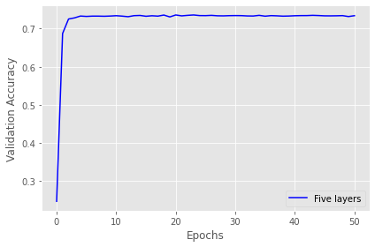

```python
print_result(nn_AdaM_onehotFive,X_train_onehot,y_train,X_test_onehot,y_test,title="Five layers",color="blue")

plt.show()
```

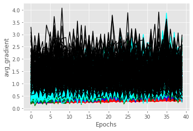

```python
plt.plot(range(len(nn_AdaM_onehotFive.gradW1_[10:])), nn_AdaM_onehotFive.gradW1_[10:], color='red')
plt.plot(range(len(nn_AdaM_onehotFive.gradW2_[10:])), nn_AdaM_onehotFive.gradW2_[10:], color='blue')
plt.plot(range(len(nn_AdaM_onehotFive.gradW3_[10:])), nn_AdaM_onehotFive.gradW3_[10:], color='green')
plt.plot(range(len(nn_AdaM_onehotFive.gradW4_[10:])), nn_AdaM_onehotFive.gradW4_[10:], color='cyan')
plt.plot(range(len(nn_AdaM_onehotFive.gradW5_[10:])), nn_AdaM_onehotFive.gradW5_[10:], color='k')
plt.ylabel('avg_gradient')


plt.xlabel('Epochs')
# plt.tight_layout()
# plt.legend(loc='best')
plt.grid(True)
```

## reference

```
[1] Lectures
[2] Dr. Larson's code
```